# Large scale drivers of trophic interactions in the Chilean coast

#### 3) Abundances

- Predatory fish vs latitude

```r
PredFish1 <- TransectGroup_mean %>%
filter(Group == "Predatory_fish") %>%
mutate(logMean = log(Total_abundance+ 1))

PredFish.lm <- lm(logMean ~ Latitude, data = PredFish1)
summary(PredFish.lm)
```

```
##
## Call:
## lm(formula = logMean ~ Latitude, data = PredFish1)
##
## Residuals:
##      Min       1Q   Median       3Q      Max
## -1.75559 -0.50348 -0.03175  0.35589  1.88663
##
## Coefficients:
##             Estimate Std. Error t value Pr(>|t|)
## (Intercept)   7.1114     1.4009   5.076  0.00048 ***
## Latitude     -0.1278     0.0458  -2.789  0.01914 *
## ---
## Signif. codes:  0 '***' 0.001 '**' 0.01 '*' 0.05 '.' 0.1 ' ' 1
##
## Residual standard error: 1.085 on 10 degrees of freedom
## Multiple R-squared:  0.4376, Adjusted R-squared:  0.3814
## F-statistic: 7.781 on 1 and 10 DF,  p-value: 0.01914
```

There is a correlation between abundance of predatory fish and latitude.

- Herbivorous fish vs latitude

```r
HerbFish1 <- TransectGroup_mean %>%
filter(Group == "Herbivore_fish") %>%
mutate(logMean = log(Total_abundance+ 1))

HerbFish.lm <- lm(logMean ~ Latitude, data = HerbFish1)
summary(HerbFish.lm)
```

```
##
## Call:
## lm(formula = logMean ~ Latitude, data = HerbFish1)
##
## Residuals:
##     Min      1Q  Median      3Q     Max
## -0.7530 -0.5506 -0.2243  0.4681  1.0725
##
## Coefficients:
##             Estimate Std. Error t value Pr(>|t|)
## (Intercept)  0.29230    0.94196   0.310    0.763
## Latitude     0.01099    0.03080   0.357    0.729
##
## Residual standard error: 0.7295 on 10 degrees of freedom
## Multiple R-squared:  0.01257,    Adjusted R-squared:  -0.08617
## F-statistic: 0.1274 on 1 and 10 DF,  p-value: 0.7286
```

There is a not correlation between abundance of herbivorous fish and latitude.

- Predatory crabs vs latitude

```r
PredCrab1 <- TransectGroup_mean %>%
filter(Group == "Predatory_crab") %>%
mutate(logMean = log(Total_abundance+ 1))

PredCrab.lm <- lm(logMean ~ Latitude, data = PredCrab1)
summary(PredCrab.lm)
```

```
##
## Call:
## lm(formula = logMean ~ Latitude, data = PredCrab1)
##
## Residuals:
##     Min      1Q  Median      3Q     Max
## -1.3285 -1.0343 -0.4455  0.7352  2.6571
##
## Coefficients:
##             Estimate Std. Error t value Pr(>|t|)
## (Intercept)  0.28135    1.80265   0.156    0.879
## Latitude     0.03715    0.05893   0.630    0.543
##
## Residual standard error: 1.396 on 10 degrees of freedom
## Multiple R-squared:  0.03822,    Adjusted R-squared:  -0.05796
## F-statistic: 0.3974 on 1 and 10 DF,  p-value: 0.5426
```

There is a not correlation between abundance of predatory crabs and latitude.

- Omnivorous crabs vs latitude

```r
OCrab1 <- Transect_mean %>%
filter(Species == "Taliepus_sp.") %>%
mutate(logMean = log(Mean_abundance+ 1))

OCrab.lm <- lm(logMean ~ Latitude, data = OCrab1)
summary(OCrab.lm)
```

```
##
## Call:
## lm(formula = logMean ~ Latitude, data = OCrab1)
##
## Residuals:
##     Min      1Q  Median      3Q     Max
## -1.0810 -0.7884 -0.5550  0.9252  2.5022
##
## Coefficients:
##             Estimate Std. Error t value Pr(>|t|)
## (Intercept)  1.72352    1.55300   1.110    0.293
## Latitude    -0.03345    0.05077  -0.659    0.525
##
## Residual standard error: 1.203 on 10 degrees of freedom
## Multiple R-squared:  0.0416, Adjusted R-squared:  -0.05424
## F-statistic: 0.4341 on 1 and 10 DF,  p-value: 0.5249
```

There is a not correlation between abundance of omnivorous crabs and latitude.

- Sea stars vs latitude

```r
SS1 <- TransectGroup_mean %>%
filter(Group == "Sea_star") %>%
mutate(logMean = log(Total_abundance+ 1))

SS.lm <- lm(logMean ~ Latitude, data = SS1)
summary(SS.lm)
```

```
##
## Call:
## lm(formula = logMean ~ Latitude, data = SS1)
##
## Residuals:
##     Min      1Q  Median      3Q     Max
## -1.3616 -1.0919 -0.1602  0.9060  2.1090
##
## Coefficients:
##             Estimate Std. Error t value Pr(>|t|)
## (Intercept) -0.69859    1.63115  -0.428    0.678
## Latitude     0.06871    0.05333   1.288    0.227
##
## Residual standard error: 1.263 on 10 degrees of freedom
## Multiple R-squared:  0.1424, Adjusted R-squared:  0.05659
## F-statistic:  1.66 on 1 and 10 DF,  p-value: 0.2266
```

There is a not correlation between abundance of sea stars and latitude.

- Urchins vs latitude

```r
Urchin1 <- TransectGroup_mean %>%
filter(Group == "Urchin") %>%
mutate(logMean = log(Total_abundance+ 1))

Urchin.lm <- lm(logMean ~ Latitude, data = Urchin1)
summary(Urchin.lm)
```

```
##
## Call:
## lm(formula = logMean ~ Latitude, data = Urchin1)
##
## Residuals:
##     Min      1Q  Median      3Q     Max
## -2.3330 -2.0145 -0.4054  1.0647  4.1357
##
## Coefficients:
##             Estimate Std. Error t value Pr(>|t|)
## (Intercept)  2.88433    2.96418   0.973    0.353
## Latitude    -0.01956    0.09691  -0.202    0.844
##
## Residual standard error: 2.296 on 10 degrees of freedom
## Multiple R-squared:  0.004057,   Adjusted R-squared:  -0.09554
## F-statistic: 0.04074 on 1 and 10 DF,  p-value: 0.8441
```

There is a not correlation between abundance of urchins and latitude.

- Herbivorous gastropods vs latitude

```r
HG1 <- TransectGroup_mean %>%
filter(Group == "Herbivore_gastropod") %>%
mutate(logMean = log(Total_abundance+ 1))

HG.lm <- lm(logMean ~ Latitude, data = HG1)
summary(HG.lm)
```

```
##
## Call:
## lm(formula = logMean ~ Latitude, data = HG1)
##
## Residuals:
##    Min     1Q Median     3Q    Max
## -3.892 -1.513 -0.955  1.740  4.975
##
## Coefficients:
##             Estimate Std. Error t value Pr(>|t|)
## (Intercept)   9.6118     3.5100   2.738   0.0209 *
## Latitude     -0.2029     0.1148  -1.768   0.1074
## ---
## Signif. codes:  0 '***' 0.001 '**' 0.01 '*' 0.05 '.' 0.1 ' ' 1
##
## Residual standard error: 2.718 on 10 degrees of freedom
## Multiple R-squared:  0.2382, Adjusted R-squared:  0.1621
## F-statistic: 3.128 on 1 and 10 DF,  p-value: 0.1074
```

There is a not correlation between abundance of herbivorous gastropods and latitude.

#### 4) Species richness

- Species Richness vs latitude

```r
Richness1 <- Richness_mean %>%
mutate(logMean = log(Mean_SR+ 1))

Richness.lm <- lm(logMean ~ Latitude, data = Richness1)
summary(Richness.lm)
```

```
##
## Call:
## lm(formula = logMean ~ Latitude, data = Richness1)
##
## Residuals:
##      Min       1Q   Median       3Q      Max
## -0.47501 -0.13152 -0.01096  0.07326  0.60061
##
## Coefficients:
##             Estimate Std. Error t value Pr(>|t|)
## (Intercept)  2.64353    0.41682   6.342 8.44e-05 ***
## Latitude    -0.01645    0.01363  -1.207    0.255
## ---
## Signif. codes:  0 '***' 0.001 '**' 0.01 '*' 0.05 '.' 0.1 ' ' 1
##
## Residual standard error: 0.3228 on 10 degrees of freedom
## Multiple R-squared:  0.1272, Adjusted R-squared:  0.03997
## F-statistic: 1.458 on 1 and 10 DF,  p-value: 0.255
```

#### 5) Fish length

- Fish length vs latitude

```r
Size1 <- Size_mean %>%
filter(Type == "Fish") %>%
mutate(logMean = log(mean_Size+ 1))

Size.lm <- lm(logMean ~ Latitude, data = Size1)
summary(Size.lm)
```

```
##
## Call:
## lm(formula = logMean ~ Latitude, data = Size1)
##
## Residuals:
##      Min       1Q   Median       3Q      Max
## -0.24312 -0.06696 -0.00236  0.08288  0.18657
##
## Coefficients:
##              Estimate Std. Error t value Pr(>|t|)
## (Intercept)  3.633444   0.169840  21.393 1.11e-09 ***
## Latitude    -0.017336   0.005553  -3.122   0.0108 *
## ---
## Signif. codes:  0 '***' 0.001 '**' 0.01 '*' 0.05 '.' 0.1 ' ' 1
##
## Residual standard error: 0.1315 on 10 degrees of freedom
## Multiple R-squared:  0.4936, Adjusted R-squared:  0.443
## F-statistic: 9.748 on 1 and 10 DF,  p-value: 0.01083
```

There is a correlation between fish length and latitude.

## **Part 4:** Latitudinal patterns in consumption

In this part, latitudinal patterns in consumption (predation and herbivory) were observed and analysed

### **4a):** Explore visual relationships

- Predation vs latitude

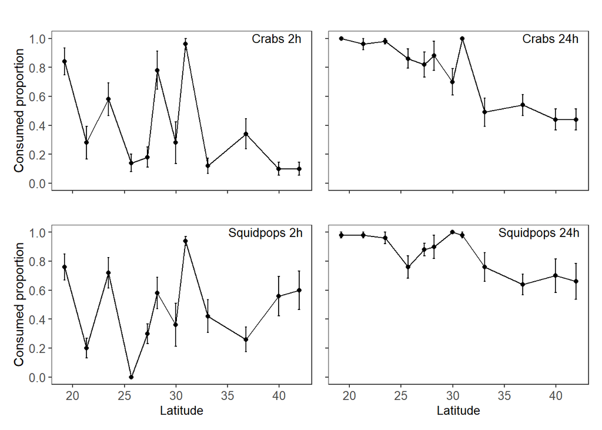

```r
Predation_sum$Latitude <- Predation_sum$Latitude*-1

#Crabs 2h
Crabs2_plot <- Predation_sum%>%
filter(Bait2 == "Crabs" & Assay_time2 == "2") %>%
ggplot(aes(x= Latitude, y=mean_consumption)) +
  geom_line() +
  geom_point()+
  geom_errorbar(aes(ymin=mean_consumption-se, ymax=mean_consumption+se), width=.2,
                 position=position_dodge(0.05)) +
Theme1 +
labs( y="Consumed proportion", x="Latitude") +
ggtitle("Crabs 2h")+
theme(axis.text.y = element_text(size = 10), axis.title.y = element_text(size = 11), axis.text.x = element_blank(), axis.title.x =     element_blank(), plot.title=element_text(hjust=0.95, vjust=-8, size=10)) + scale_y_continuous(limits = c(0, 1), breaks=seq(0, 1, 0.2))

#Squidpops 2h
Squids2_plot <- Predation_sum%>%
filter(Bait2 == "Squidpops" & Assay_time2 == "2") %>%
ggplot(aes(x= Latitude, y=mean_consumption)) +
  geom_line() +
  geom_point()+
  geom_errorbar(aes(ymin=mean_consumption-se, ymax=mean_consumption+se), width=.2,
                 position=position_dodge(0.05)) +
Theme1 +
labs( y="Consumed proportion", x="Latitude") +
ggtitle("Squidpops 2h")+
theme(axis.text.y = element_text(size = 10), axis.title.y = element_text(size = 11),
axis.text.x = element_text(size = 10), axis.title.x = element_text(size = 10),
      plot.title=element_text(hjust=0.95, vjust=-8, size=10))+ scale_y_continuous(limits = c(0, 1), breaks=seq(0, 1, 0.2))

#Crabs 24h
Crabs24_plot <- Predation_sum%>%
filter(Bait2 == "Crabs" & Assay_time2 == "24") %>%
ggplot(aes(x= Latitude, y=mean_consumption)) +
  geom_line() +
  geom_point()+
  geom_errorbar(aes(ymin=mean_consumption-se, ymax=mean_consumption+se), width=.2,
                 position=position_dodge(0.05)) +
Theme1 +
labs( y="Consumed proportion", x="Latitude") +
ggtitle("Crabs 24h")+
theme(axis.text.y = element_blank(), axis.title.y =     element_blank(), axis.text.x = element_blank(), axis.title.x =     element_blank(), plot.title=element_text(hjust=0.95, vjust=-8, size=10))+ scale_y_continuous(limits = c(0, 1), breaks=seq(0, 1, 0.2))

#Squidpops 24h
Squids24_plot <- Predation_sum%>%
filter(Bait2 == "Squidpops" & Assay_time2 == "24") %>%
ggplot(aes(x= Latitude, y=mean_consumption)) +
  geom_line() +
  geom_point()+
  geom_errorbar(aes(ymin=mean_consumption-se, ymax=mean_consumption+se), width=.2,
                 position=position_dodge(0.05)) +
Theme1 +
labs( y="Consumed proportion", x="Latitude") +
ggtitle("Squidpops 24h")+
theme(axis.text.y = element_blank(), axis.title.y =     element_blank(),
axis.text.x = element_text(size = 10), axis.title.x = element_text(size = 10), plot.title=element_text(hjust=0.95, vjust=-8, size=10))+ scale_y_continuous(limits = c(0, 1), breaks=seq(0, 1, 0.2))

Crabs2_plot + Crabs24_plot + Squids2_plot + Squids24_plot + plot_layout(ncol=2)
```

Save plot in tiff format

```r
ggsave("Predation.tiff", units="mm", width=160, height=120, dpi=300, compression = 'lzw')
```

- Herbivory vs latitude

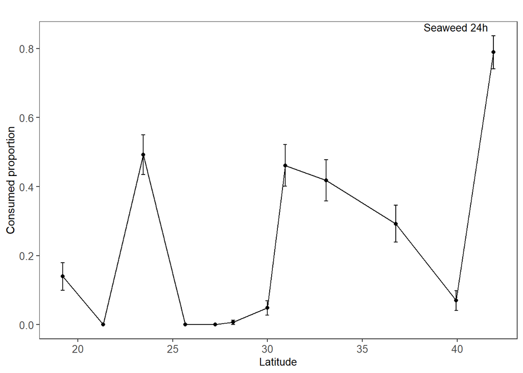

```r
Herbivory_sum$Latitude <- Herbivory_sum$Latitude*-1

Herbivory_sum %>%
ggplot(aes(x= Latitude, y= mean_consumption)) +
  geom_line() +
  geom_point()+
  geom_errorbar(aes(ymin=mean_consumption-se, ymax=mean_consumption+se), width=.2,
                 position=position_dodge(0.05)) +
Theme1 +
labs( y="Consumed proportion", x="Latitude") +
ggtitle("Seaweed 24h")+
theme(axis.text.y = element_text(size = 10), axis.title.y = element_text(size = 11), axis.text.x = element_text(size = 10), axis.title.x =     element_text(size = 10), plot.title=element_text(hjust=0.93, vjust=-8, size=10))
```

```r
ggsave("Seaweed24.tiff", units="mm", width=80, height=60, dpi=300, compression = 'lzw')
```

### **4b):** Analise relationships

- Crabs 2h vs latitude

```r
Crab2 <- Predation_sum %>%
filter(Bait2 == "Crabs" & Assay_time2 == "2") %>%
mutate(logMean = log(mean_consumption + 1))

Crab2.lm <- lm(logMean ~ Latitude, data = Crab2)
summary(Crab2.lm)
```

```
##
## Call:
## lm(formula = logMean ~ Latitude, data = Crab2)
##
## Residuals:
##      Min       1Q   Median       3Q      Max
## -0.23717 -0.15619 -0.04944  0.10017  0.38032
##
## Coefficients:
##              Estimate Std. Error t value Pr(>|t|)
## (Intercept)  0.736480   0.255296   2.885   0.0163 *
## Latitude    -0.014351   0.008346  -1.719   0.1163
## ---
## Signif. codes:  0 '***' 0.001 '**' 0.01 '*' 0.05 '.' 0.1 ' ' 1
##
## Residual standard error: 0.1977 on 10 degrees of freedom
## Multiple R-squared:  0.2282, Adjusted R-squared:  0.151
## F-statistic: 2.956 on 1 and 10 DF,  p-value: 0.1163
```

There is not a correlation between crab consumed proportion after 2 h and latitude.

- Crabs 24h vs latitude

```r
Crab24 <- Predation_sum %>%
filter(Bait2 == "Crabs" & Assay_time2 == "24") %>%
mutate(logMean = log(mean_consumption + 1))

Crab24.lm <- lm(logMean ~ Latitude, data = Crab24)
summary(Crab24.lm)
```

```
##
## Call:
## lm(formula = logMean ~ Latitude, data = Crab24)
##
## Residuals:
##       Min        1Q    Median        3Q       Max
## -0.104230 -0.023943 -0.007637  0.010691  0.154568
##
## Coefficients:
##              Estimate Std. Error t value Pr(>|t|)
## (Intercept)  1.048074   0.082560  12.695 1.72e-07 ***
## Latitude    -0.016473   0.002699  -6.103 0.000115 ***
## ---
## Signif. codes:  0 '***' 0.001 '**' 0.01 '*' 0.05 '.' 0.1 ' ' 1
##
## Residual standard error: 0.06394 on 10 degrees of freedom
## Multiple R-squared:  0.7883, Adjusted R-squared:  0.7672
## F-statistic: 37.25 on 1 and 10 DF,  p-value: 0.0001152
```

There is a correlation between crab consumed proportion after 24 h and latitude.

- Squidpops 2h vs latitude

```r
Squids2 <- Predation_sum %>%
filter(Bait2 == "Squidpops" & Assay_time2 == "2") %>%
mutate(logMean = log(mean_consumption + 1))

Squids2.lm <- lm(logMean ~ Latitude, data = Squids2)
summary(Squids2.lm)
```

```
##
## Call:
## lm(formula = logMean ~ Latitude, data = Squids2)
##
## Residuals:
##      Min       1Q   Median       3Q      Max
## -0.36308 -0.11805  0.00856  0.11235  0.28698
##
## Coefficients:
##             Estimate Std. Error t value Pr(>|t|)
## (Intercept) 0.301586   0.251945   1.197    0.259
## Latitude    0.002396   0.008237   0.291    0.777
##
## Residual standard error: 0.1951 on 10 degrees of freedom
## Multiple R-squared:  0.008394,   Adjusted R-squared:  -0.09077
## F-statistic: 0.08465 on 1 and 10 DF,  p-value: 0.777
```

There is not a correlation between squidpops consumed proportion after 2 h and latitude.

- Squidpops 24h vs latitude

```r
Squids24 <- Predation_sum %>%
filter(Bait2 == "Squidpops" & Assay_time2 == "24") %>%
mutate(logMean = log(mean_consumption + 1))

Squids24.lm <- lm(logMean ~ Latitude, data = Squids24)
summary(Squids24.lm)
```

```
##
## Call:
## lm(formula = logMean ~ Latitude, data = Squids24)
##
## Residuals:
##       Min        1Q    Median        3Q       Max
## -0.081493 -0.017758 -0.000857  0.009900  0.081958
##
## Coefficients:
##              Estimate Std. Error t value Pr(>|t|)
## (Intercept)  0.858258   0.063827  13.447 9.95e-08 ***
## Latitude    -0.008240   0.002087  -3.949  0.00274 **
## ---
## Signif. codes:  0 '***' 0.001 '**' 0.01 '*' 0.05 '.' 0.1 ' ' 1
##
## Residual standard error: 0.04943 on 10 degrees of freedom
## Multiple R-squared:  0.6092, Adjusted R-squared:  0.5702
## F-statistic: 15.59 on 1 and 10 DF,  p-value: 0.002736
```

There is a correlation between squidpops consumed proportion after 24 h and latitude.

- Seaweed 24h vs latitude

```r
Seaweed24 <- Herbivory_sum %>%
mutate(logMean = log(mean_consumption + 1))

Seaweed24.lm <- lm(logMean ~ Latitude, data = Seaweed24)
summary(Seaweed24.lm)
```

```
##
## Call:
## lm(formula = logMean ~ Latitude, data = Seaweed24)
##
## Residuals:
##      Min       1Q   Median       3Q      Max
## -0.24648 -0.14313 -0.04695  0.13700  0.29650
##
## Coefficients:
##              Estimate Std. Error t value Pr(>|t|)
## (Intercept) -0.194682   0.242519  -0.803    0.441
## Latitude     0.012734   0.007929   1.606    0.139
##
## Residual standard error: 0.1878 on 10 degrees of freedom
## Multiple R-squared:  0.2051, Adjusted R-squared:  0.1256
## F-statistic: 2.579 on 1 and 10 DF,  p-value: 0.1393
```

## **Part 5:** Predation intensity: Effect of site-specific variables

First, create datasets to be used in the analysis

```r
Predation_analysis <- Predation_5 %>%
  select(-Rope, -Bait, -Camera, -Assay_time, -Initial_Individuals, -Remaining_individuals, -Survival_proportion,-Consumed_proportion)

#Separate by Bait and Assay time

Crabs_24 <- filter(Predation_analysis, Bait2 == "Crabs" & Assay_time2 == 24)
Crabs_2 <- filter(Predation_analysis, Bait2 == "Crabs" & Assay_time2 == 2)
Squidpops_24 <- filter(Predation_analysis, Bait2 == "Squidpops" & Assay_time2 == 24)
Squidpops_2 <- filter(Predation_analysis, Bait2 == "Squidpops" & Assay_time2 == 2)
```

### **5a):** Standardize

```r
#Crabs 24h
Crabs24_num <- Crabs_24 %>%
  select(-Site, -Bait2, -Assay_time2, -Consumed_individuals)
Crabs24_stand <- decostand(Crabs24_num, method="range", na.rm = TRUE)
Crabs24_stand$Site <- Crabs_24$Site
Crabs24_stand$Consumed_individuals<- Crabs_24$Consumed_individuals
#Crabs 2h
Crabs2_num <- Crabs_2 %>%
  select(-Site, -Bait2, -Assay_time2, -Consumed_individuals)
Crabs2_stand <- decostand(Crabs2_num, method="range", na.rm = TRUE)
Crabs2_stand$Site <- Crabs_2$Site
Crabs2_stand$Consumed_individuals<- Crabs_2$Consumed_individuals
#Squidpops 24h
Squidpops24_num <- Squidpops_24 %>%
  select(-Site, -Bait2, -Assay_time2, -Consumed_individuals)
Squidpops24_stand <- decostand(Squidpops24_num, method="range", na.rm = TRUE)
Squidpops24_stand$Site <- Squidpops_24$Site
Squidpops24_stand$Consumed_individuals<- Squidpops_24$Consumed_individuals
#Squidpops 2h
Squidpops2_num <- Squidpops_2 %>%
  select(-Site, -Bait2, -Assay_time2, -Consumed_individuals)
Squidpops2_stand <- decostand(Squidpops2_num, method="range", na.rm = TRUE)
Squidpops2_stand$Site <- Squidpops_2$Site
Squidpops2_stand$Consumed_individuals<- Squidpops_2$Consumed_individuals
```

### **5b)** Model selection: Crabs 2h

This code was supplied by Dr. Joel Williams.

**1)** Model selection loop

```r
## step 1 mode selection loop
m1s <- list()
for(i in c("Temperature", "D_oxygen_mgL","Salinity_ppt","RPM", "V_Visibility", "Kelp", "Understorey_algae", "Mean_SR", "Predatory_crab", "Sea_star", "Predatory_fish","Fish_size")) {
  cat(i," ")
  cmd <- paste("gamm4(Consumed_individuals ~ ",i, ",data = Crabs2_stand, random =~(1|Site), family = poisson)") # The model formula with random factors and distribution etc. i represent each individual variable from the list above
  m1s[[i]] <- eval(parse(text=cmd))
}
```

```
## Temperature  D_oxygen_mgL  Salinity_ppt  RPM  V_Visibility  Kelp  Understorey_algae  Mean_SR  Predatory_crab  Sea_star  Predatory_fish  Fish_size
```

```r
# This loop prints the summary(m1) for every model into a text file. Could be handy for writing the paper
sink("temp.txt")
for(i in names(m1s)) {
  cat("\n *****",i,"****\n\n")
  print(summary(m1s[[i]]$mer))
  print(summary(m1s[[i]]$gam))
}
```

```
##
##  ***** Temperature ****
##
## Generalized linear mixed model fit by maximum likelihood (Laplace
##   Approximation) [glmerMod]
##  Family: poisson  ( log )
##
##      AIC      BIC   logLik deviance df.resid
##    420.1    428.4   -207.0    414.1      117
##
## Scaled residuals:
##      Min       1Q   Median       3Q      Max
## -1.93381 -0.92312  0.06015  0.65176  2.79744
##
## Random effects:
##  Groups Name        Variance Std.Dev.
##  Site   (Intercept) 0.2979   0.5458
## Number of obs: 120, groups:  Site, 12
##
## Fixed effects:
##              Estimate Std. Error z value Pr(>|z|)
## X(Intercept)  -0.8086     0.4487  -1.802  0.07151 .
## XTemperature   1.8546     0.6104   3.038  0.00238 **
## ---
## Signif. codes:  0 '***' 0.001 '**' 0.01 '*' 0.05 '.' 0.1 ' ' 1
##
## Correlation of Fixed Effects:
##             X(Int)
## XTemperatur -0.918
##
## Family: poisson
## Link function: log
##
## Formula:
## Consumed_individuals ~ Temperature
##
## Parametric coefficients:
##             Estimate Std. Error z value Pr(>|z|)
## (Intercept)  -0.8086     0.4493  -1.800  0.07192 .
## Temperature   1.8546     0.6116   3.032  0.00243 **
```

[output cut: 473 more lines]

```
##
## Family: poisson
## Link function: log
##
## Formula:
## Consumed_individuals ~ Fish_size
##
## Parametric coefficients:
##             Estimate Std. Error z value Pr(>|z|)
## (Intercept)  0.06379    0.60461   0.106    0.916
## Fish_size    0.52233    0.89520   0.583    0.560
##
##
## R-sq.(adj) =  -0.0111
## glmer.ML = 171.02  Scale est. = 1         n = 120
```

```r
sink()
# This line will list in order the AIC for each model. Select the variable with the lowest AIC and place it in the model formula in Step 2.
sort(sapply(m1s,function(x) AIC(x$mer)))
```

```
##       Temperature      D_oxygen_mgL              Kelp      Salinity_ppt
##          420.0849          422.3158          424.1537          424.3317
##           Mean_SR          Sea_star    Predatory_crab    Predatory_fish
##          424.9734          425.3614          426.1651          426.6511
##         Fish_size Understorey_algae               RPM      V_Visibility
##          426.7192          426.8924          427.0288          427.0557
```

**2)** Start with the first variable (the lowest AIC)

```r
m2s <- list()
cov <- c("D_oxygen_mgL","Salinity_ppt","RPM", "V_Visibility", "Kelp", "Understorey_algae", "Mean_SR", "Predatory_crab", "Sea_star", "Predatory_fish","Fish_size")
for(i in cov) {
  cat(i," ")
  cmd <- paste("gamm4(Consumed_individuals ~  Temperature + ",i, ",data = Crabs2_stand, random =~(1|Site) , family = poisson)")
  m2s[[i]] <- eval(parse(text=cmd))
}
```

```
## D_oxygen_mgL  Salinity_ppt  RPM  V_Visibility  Kelp  Understorey_algae  Mean_SR  Predatory_crab  Sea_star  Predatory_fish  Fish_size
```

```r
sink("temp.txt")
for(i in names(m2s)) {
  cat("\n *****",i,"****\n\n")
  print(summary(m2s[[i]]$mer))
  print(summary(m2s[[i]]$gam))
}
```

```
##
##  ***** D_oxygen_mgL ****
##
## Generalized linear mixed model fit by maximum likelihood (Laplace
##   Approximation) [glmerMod]
##  Family: poisson  ( log )
##
##      AIC      BIC   logLik deviance df.resid
##    419.9    431.1   -206.0    411.9      116
##
## Scaled residuals:
##      Min       1Q   Median       3Q      Max
## -1.96262 -0.90296  0.06282  0.58499  2.95138
##
## Random effects:
##  Groups Name        Variance Std.Dev.
##  Site   (Intercept) 0.2282   0.4777
## Number of obs: 120, groups:  Site, 12
##
## Fixed effects:
##               Estimate Std. Error z value Pr(>|z|)
## X(Intercept)   -0.9362     0.4211  -2.223   0.0262 *
## XTemperature    1.4255     0.6203   2.298   0.0216 *
## XD_oxygen_mgL   0.9309     0.5945   1.566   0.1174
## ---
## Signif. codes:  0 '***' 0.001 '**' 0.01 '*' 0.05 '.' 0.1 ' ' 1
##
## Correlation of Fixed Effects:
##             X(Int) XTmprt
## XTemperatur -0.711
## XD_xygn_mgL -0.214 -0.443
##
## Family: poisson
## Link function: log
##
## Formula:
## Consumed_individuals ~ Temperature + D_oxygen_mgL
##
## Parametric coefficients:
##              Estimate Std. Error z value Pr(>|z|)
```

[output cut: 484 more lines]

```
##
## Formula:
## Consumed_individuals ~ Temperature + Fish_size
##
## Parametric coefficients:
##             Estimate Std. Error z value Pr(>|z|)
## (Intercept)  -0.5058     0.4934  -1.025 0.305269
## Temperature   2.2603     0.6764   3.342 0.000833 ***
## Fish_size    -0.9076     0.7854  -1.156 0.247849
## ---
## Signif. codes:  0 '***' 0.001 '**' 0.01 '*' 0.05 '.' 0.1 ' ' 1
##
##
## R-sq.(adj) =  0.285
## glmer.ML = 172.23  Scale est. = 1         n = 120
```

```r
sink()
sort(sapply(m2s,function(x) AIC(x$mer)))
```

```
##      V_Visibility           Mean_SR      D_oxygen_mgL    Predatory_crab
##          418.4415          418.6334          419.9044          420.3674
##              Kelp         Fish_size               RPM          Sea_star
##          420.7648          420.8228          420.9974          421.0531
##      Salinity_ppt Understorey_algae    Predatory_fish
##          421.4708          421.8412          422.0790
```

**3)** Start with temperature and visibility (two variables that best explain)

```r
m3s <- list()
cov <- c("D_oxygen_mgL","Salinity_ppt","RPM", "Kelp", "Understorey_algae", "Mean_SR", "Predatory_crab", "Sea_star", "Predatory_fish","Fish_size")
for(i in cov) {
  cat(i," ")
  cmd <- paste("gamm4(Consumed_individuals ~ Temperature + V_Visibility + ",i, ",data = Crabs2_stand, random =~(1|Site) , family = poisson)")
  m3s[[i]] <- eval(parse(text=cmd))
}
```

```
## D_oxygen_mgL  Salinity_ppt  RPM  Kelp  Understorey_algae  Mean_SR  Predatory_crab  Sea_star  Predatory_fish  Fish_size
```

```r
sink("temp3.txt")
for(i in names(m3s)) {
  cat("\n *****",i,"****\n\n")
  print(summary(m3s[[i]]$mer))
  print(summary(m3s[[i]]$gam))
}
```

```
##
##  ***** D_oxygen_mgL ****
##
## Generalized linear mixed model fit by maximum likelihood (Laplace
##   Approximation) [glmerMod]
##  Family: poisson  ( log )
##
##      AIC      BIC   logLik deviance df.resid
##    419.7    433.7   -204.9    409.7      115
##
## Scaled residuals:
##     Min      1Q  Median      3Q     Max
## -1.9471 -0.8827  0.0458  0.6202  3.0120
##
## Random effects:
##  Groups Name        Variance Std.Dev.
##  Site   (Intercept) 0.1907   0.4366
## Number of obs: 120, groups:  Site, 12
##
## Fixed effects:
##               Estimate Std. Error z value Pr(>|z|)
## X(Intercept)   -1.6362     0.6195  -2.641  0.00826 **
## XTemperature    2.0619     0.7193   2.867  0.00415 **
## XV_Visibility   1.1079     0.7322   1.513  0.13022
## XD_oxygen_mgL   0.5306     0.6112   0.868  0.38531
## ---
## Signif. codes:  0 '***' 0.001 '**' 0.01 '*' 0.05 '.' 0.1 ' ' 1
##
## Correlation of Fixed Effects:
##             X(Int) XTmprt XV_Vsb
## XTemperatur -0.822
## XV_Visiblty -0.774  0.595
## XD_xygn_mgL  0.211 -0.582 -0.426
##
## Family: poisson
## Link function: log
##
## Formula:
## Consumed_individuals ~ Temperature + V_Visibility + D_oxygen_mgL
##
```

[output cut: 465 more lines]

```
## Formula:
## Consumed_individuals ~ Temperature + V_Visibility + Fish_size
##
## Parametric coefficients:
##              Estimate Std. Error z value Pr(>|z|)
## (Intercept)   -1.4786     0.7222  -2.047   0.0406 *
## Temperature    2.5997     0.6375   4.078 4.54e-05 ***
## V_Visibility   1.2328     0.6977   1.767   0.0772 .
## Fish_size     -0.5257     0.7464  -0.704   0.4812
## ---
## Signif. codes:  0 '***' 0.001 '**' 0.01 '*' 0.05 '.' 0.1 ' ' 1
##
##
## R-sq.(adj) =  0.297
## glmer.ML =  172.4  Scale est. = 1         n = 120
```

```r
sink()
sort(sapply(m3s,function(x) AIC(x$mer)))
```

```
##    Predatory_crab              Kelp           Mean_SR    Predatory_fish
##          417.9956          418.5899          419.2701          419.3668
## Understorey_algae      D_oxygen_mgL               RPM         Fish_size
##          419.3678          419.7158          419.7867          419.9574
##          Sea_star      Salinity_ppt
##          420.2456          420.3914
```

**4)** Start with temperature, visibility and predatory crab

```r
m3s <- list()
cov <- c("D_oxygen_mgL","Salinity_ppt","RPM", "Kelp", "Understorey_algae", "Mean_SR", "Sea_star", "Predatory_fish","Fish_size")
for(i in cov) {
  cat(i," ")
  cmd <- paste("gamm4(Consumed_individuals ~ Temperature + V_Visibility + Predatory_crab + ",i, ",data = Crabs2_stand, random =~(1|Site) , family = poisson)")
  m3s[[i]] <- eval(parse(text=cmd))
}
```

```
## D_oxygen_mgL  Salinity_ppt  RPM  Kelp  Understorey_algae  Mean_SR  Sea_star  Predatory_fish  Fish_size
```

```r
sink("temp3.txt")
for(i in names(m3s)) {
  cat("\n *****",i,"****\n\n")
  print(summary(m3s[[i]]$mer))
  print(summary(m3s[[i]]$gam))
}
```

```
##
##  ***** D_oxygen_mgL ****
##
## Generalized linear mixed model fit by maximum likelihood (Laplace
##   Approximation) [glmerMod]
##  Family: poisson  ( log )
##
##      AIC      BIC   logLik deviance df.resid
##    419.8    436.5   -203.9    407.8      114
##
## Scaled residuals:
##      Min       1Q   Median       3Q      Max
## -1.94525 -0.91198  0.07735  0.59297  2.89199
##
## Random effects:
##  Groups Name        Variance Std.Dev.
##  Site   (Intercept) 0.1421   0.377
## Number of obs: 120, groups:  Site, 12
##
## Fixed effects:
##                 Estimate Std. Error z value Pr(>|z|)
## X(Intercept)     -1.5539     0.5606  -2.772 0.005574 **
## XTemperature      2.2452     0.6645   3.379 0.000729 ***
## XV_Visibility     1.2454     0.6718   1.854 0.063756 .
## XPredatory_crab  -0.8390     0.5794  -1.448 0.147609
## XD_oxygen_mgL     0.2681     0.5768   0.465 0.642026
## ---
## Signif. codes:  0 '***' 0.001 '**' 0.01 '*' 0.05 '.' 0.1 ' ' 1
##
## Correlation of Fixed Effects:
##             X(Int) XTmprt XV_Vsb XPrdt_
## XTemperatur -0.796
## XV_Visiblty -0.749  0.609
## XPrdtry_crb -0.038 -0.214 -0.182
## XD_xygn_mgL  0.197 -0.611 -0.463  0.297
##
## Family: poisson
## Link function: log
##
## Formula:
```

[output cut: 449 more lines]

```
##     Fish_size
##
## Parametric coefficients:
##                Estimate Std. Error z value Pr(>|z|)
## (Intercept)     -1.4365     0.6458  -2.224   0.0261 *
## Temperature      2.5375     0.5658   4.485 7.29e-06 ***
## V_Visibility     1.2977     0.6220   2.086   0.0369 *
## Predatory_crab  -0.8773     0.5609  -1.564   0.1178
## Fish_size       -0.3297     0.6830  -0.483   0.6293
## ---
## Signif. codes:  0 '***' 0.001 '**' 0.01 '*' 0.05 '.' 0.1 ' ' 1
##
##
## R-sq.(adj) =  0.374
## glmer.ML = 173.78  Scale est. = 1         n = 120
```

```r
sink()
sort(sapply(m3s,function(x) AIC(x$mer)))
```

```
## Understorey_algae           Mean_SR              Kelp               RPM
##          417.6274          418.1556          418.8873          419.1228
##    Predatory_fish          Sea_star         Fish_size      D_oxygen_mgL
##          419.5635          419.7033          419.7672          419.7825
##      Salinity_ppt
##          419.9454
```

**5)** Start with temperature, visibility, predatory crab and understorey algae

```r
m3s <- list()
cov <- c("D_oxygen_mgL","Salinity_ppt","RPM", "Kelp", "Mean_SR", "Sea_star", "Predatory_fish","Fish_size")
for(i in cov) {
  cat(i," ")
  cmd <- paste("gamm4(Consumed_individuals ~ Temperature + V_Visibility + Predatory_crab + Understorey_algae + ",i, ",data = Crabs2_stand, random =~(1|Site) , family = poisson)")
  m3s[[i]] <- eval(parse(text=cmd))
}
```

```
## D_oxygen_mgL  Salinity_ppt  RPM  Kelp  Mean_SR  Sea_star  Predatory_fish  Fish_size
```

```r
sink("temp3.txt")
for(i in names(m3s)) {
  cat("\n *****",i,"****\n\n")
  print(summary(m3s[[i]]$mer))
  print(summary(m3s[[i]]$gam))
}
```

```
##
##  ***** D_oxygen_mgL ****
##
## Generalized linear mixed model fit by maximum likelihood (Laplace
##   Approximation) [glmerMod]
##  Family: poisson  ( log )
##
##      AIC      BIC   logLik deviance df.resid
##    419.3    438.8   -202.7    405.3      113
##
## Scaled residuals:
##      Min       1Q   Median       3Q      Max
## -1.88023 -0.95786  0.00846  0.70551  2.73209
##
## Random effects:
##  Groups Name        Variance Std.Dev.
##  Site   (Intercept) 0.1022   0.3196
## Number of obs: 120, groups:  Site, 12
##
## Fixed effects:
##                    Estimate Std. Error z value Pr(>|z|)
## X(Intercept)        -1.4638     0.5056  -2.895 0.003786 **
## XTemperature         2.2816     0.5990   3.809 0.000139 ***
## XV_Visibility        1.3843     0.6208   2.230 0.025747 *
## XPredatory_crab     -1.0431     0.5595  -1.864 0.062258 .
## XUnderstorey_algae  -0.5745     0.3491  -1.645 0.099874 .
## XD_oxygen_mgL        0.2951     0.5175   0.570 0.568498
## ---
## Signif. codes:  0 '***' 0.001 '**' 0.01 '*' 0.05 '.' 0.1 ' ' 1
##
## Correlation of Fixed Effects:
##             X(Int) XTmprt XV_Vsb XPrdt_ XUndr_
## XTemperatur -0.797
## XV_Visiblty -0.720  0.604
## XPrdtry_crb -0.026 -0.222 -0.222
## XUndrstry_l -0.054 -0.056 -0.150  0.158
## XD_xygn_mgL  0.219 -0.610 -0.478  0.264 -0.034
##
## Family: poisson
## Link function: log
```

[output cut: 417 more lines]

```
##
## Parametric coefficients:
##                   Estimate Std. Error z value Pr(>|z|)
## (Intercept)        -1.6047     0.6181  -2.596  0.00943 **
## Temperature         2.4557     0.5188   4.733 2.21e-06 ***
## V_Visibility        1.6059     0.6093   2.635  0.00840 **
## Predatory_crab     -1.1465     0.5515  -2.079  0.03764 *
## Understorey_algae  -0.6050     0.3971  -1.524  0.12760
## Fish_size           0.1425     0.7134   0.200  0.84170
## ---
## Signif. codes:  0 '***' 0.001 '**' 0.01 '*' 0.05 '.' 0.1 ' ' 1
##
##
## R-sq.(adj) =  0.366
## glmer.ML = 174.17  Scale est. = 1         n = 120
```

```r
sink()
sort(sapply(m3s,function(x) AIC(x$mer)))
```

```
##           Kelp       Sea_star            RPM   Salinity_ppt   D_oxygen_mgL
##       418.2539       418.6319       418.7534       419.2242       419.3116
##        Mean_SR Predatory_fish      Fish_size
##       419.3673       419.4942       419.5874
```

No improvement

**6)** Check final model

```r
finalmodel_Crabs2 <- gamm4(Consumed_individuals ~ Temperature + V_Visibility + Predatory_crab + Understorey_algae, data = Crabs2_stand, random =~(1|Site) , family = poisson)
summary(finalmodel_Crabs2$mer)
```

```
## Generalized linear mixed model fit by maximum likelihood (Laplace
##   Approximation) [glmerMod]
##  Family: poisson  ( log )
##
##      AIC      BIC   logLik deviance df.resid
##    417.6    434.4   -202.8    405.6      114
##
## Scaled residuals:
##     Min      1Q  Median      3Q     Max
## -1.8654 -0.9548  0.0305  0.7103  2.7198
##
## Random effects:
##  Groups Name        Variance Std.Dev.
##  Site   (Intercept) 0.109    0.3301
## Number of obs: 120, groups:  Site, 12
##
## Fixed effects:
##                    Estimate Std. Error z value Pr(>|z|)
## X(Intercept)        -1.5328     0.5034  -3.045  0.00233 **
## XTemperature         2.4930     0.4842   5.149 2.62e-07 ***
## XV_Visibility        1.5563     0.5558   2.800  0.00511 **
## XPredatory_crab     -1.1194     0.5458  -2.051  0.04027 *
## XUnderstorey_algae  -0.5699     0.3567  -1.598  0.11010
## ---
## Signif. codes:  0 '***' 0.001 '**' 0.01 '*' 0.05 '.' 0.1 ' ' 1
##
## Correlation of Fixed Effects:
##             X(Int) XTmprt XV_Vsb XPrdt_
## XTemperatur -0.859
## XV_Visiblty -0.722  0.459
## XPrdtry_crb -0.086 -0.080 -0.117
## XUndrstry_l -0.049 -0.094 -0.193  0.170
```

```r
summary(finalmodel_Crabs2$gam)
```

```
##
## Family: poisson
## Link function: log
##
## Formula:
## Consumed_individuals ~ Temperature + V_Visibility + Predatory_crab +
##     Understorey_algae
##
## Parametric coefficients:
##                   Estimate Std. Error z value Pr(>|z|)
## (Intercept)        -1.5328     0.5002  -3.064  0.00218 **
## Temperature         2.4930     0.4845   5.146 2.67e-07 ***
## V_Visibility        1.5563     0.5559   2.799  0.00512 **
## Predatory_crab     -1.1194     0.5371  -2.084  0.03716 *
## Understorey_algae  -0.5699     0.3563  -1.600  0.10966
## ---
## Signif. codes:  0 '***' 0.001 '**' 0.01 '*' 0.05 '.' 0.1 ' ' 1
##
##
## R-sq.(adj) =  0.371
## glmer.ML = 174.18  Scale est. = 1         n = 120
```

```r
anova(finalmodel_Crabs2$gam)
```

```
##
## Family: poisson
## Link function: log
##
## Formula:
## Consumed_individuals ~ Temperature + V_Visibility + Predatory_crab +
##     Understorey_algae
##
## Parametric Terms:
##                   df Chi.sq  p-value
## Temperature        1 26.477 2.67e-07
## V_Visibility       1  7.836  0.00512
## Predatory_crab     1  4.343  0.03716
## Understorey_algae  1  2.559  0.10966
```

Temperature is the variable that best explain the variation. Visibility, abundances of predatory crab and understorey algae cover are part of the final model. There is a significant relationship between crabs consumption temperature, visibility and abundance of predatory crabs.

**7)** Plotting prediction

### **5c)** Model selection: Crabs 24

**1)** Model selection loop

```r
m1s <- list()
for(i in c("Temperature", "D_oxygen_mgL","Salinity_ppt","RPM", "V_Visibility", "Kelp", "Understorey_algae", "Mean_SR", "Predatory_crab", "Sea_star", "Predatory_fish","Fish_size")) {
  cat(i," ")
  cmd <- paste("gamm4(Consumed_individuals ~ ",i, ",data = Crabs24_stand, random =~(1|Site), family = poisson)")

  m1s[[i]] <- eval(parse(text=cmd))
}
```

```
## Temperature  D_oxygen_mgL  Salinity_ppt  RPM  V_Visibility  Kelp  Understorey_algae  Mean_SR  Predatory_crab  Sea_star  Predatory_fish  Fish_size
```

```r
sink("temp.txt")
for(i in names(m1s)) {
  cat("\n *****",i,"****\n\n")
  print(summary(m1s[[i]]$mer))
  print(summary(m1s[[i]]$gam))
}
```

```
##
##  ***** Temperature ****
##
## Generalized linear mixed model fit by maximum likelihood (Laplace
##   Approximation) [glmerMod]
##  Family: poisson  ( log )
##
##      AIC      BIC   logLik deviance df.resid
##    438.7    447.1   -216.4    432.7      117
##
## Scaled residuals:
##     Min      1Q  Median      3Q     Max
## -2.1336 -0.2824  0.1619  0.4568  1.3189
##
## Random effects:
##  Groups Name        Variance  Std.Dev.
##  Site   (Intercept) 0.0003175 0.01782
## Number of obs: 120, groups:  Site, 12
##
## Fixed effects:
##              Estimate Std. Error z value Pr(>|z|)
## X(Intercept)   0.7379     0.1353   5.456 4.88e-08 ***
## XTemperature   0.8747     0.1776   4.925 8.42e-07 ***
## ---
## Signif. codes:  0 '***' 0.001 '**' 0.01 '*' 0.05 '.' 0.1 ' ' 1
##
## Correlation of Fixed Effects:
##             X(Int)
## XTemperatur -0.936
##
## Family: poisson
## Link function: log
##
## Formula:
## Consumed_individuals ~ Temperature
##
## Parametric coefficients:
##             Estimate Std. Error z value Pr(>|z|)
## (Intercept)   0.7379     0.1351   5.461 4.73e-08 ***
## Temperature   0.8747     0.1776   4.925 8.43e-07 ***
```

[output cut: 497 more lines]

```
## Link function: log
##
## Formula:
## Consumed_individuals ~ Fish_size
##
## Parametric coefficients:
##             Estimate Std. Error z value Pr(>|z|)
## (Intercept)   0.8921     0.1925   4.635 3.57e-06 ***
## Fish_size     0.6622     0.2794   2.370   0.0178 *
## ---
## Signif. codes:  0 '***' 0.001 '**' 0.01 '*' 0.05 '.' 0.1 ' ' 1
##
##
## R-sq.(adj) =  0.124
## glmer.ML = 53.865  Scale est. = 1         n = 120
```

```r
sink()
sort(sapply(m1s,function(x) AIC(x$mer)))
```

```
##       Temperature      Salinity_ppt         Fish_size              Kelp
##          438.7300          442.9628          448.2015          448.5564
##          Sea_star           Mean_SR      V_Visibility      D_oxygen_mgL
##          449.3811          451.4286          452.3045          452.3475
##    Predatory_crab    Predatory_fish               RPM Understorey_algae
##          452.6868          452.7114          452.8163          452.9925
```

**2)** Starting with the first variable (the lowest AIC)

```r
m2s <- list()
cov <- c("D_oxygen_mgL","Salinity_ppt","RPM", "V_Visibility", "Kelp", "Understorey_algae", "Mean_SR", "Predatory_crab", "Sea_star", "Predatory_fish","Fish_size")
for(i in cov) {
  cat(i," ")
  cmd <- paste("gamm4(Consumed_individuals ~ Temperature + ",i, ",data = Crabs24_stand, random =~(1|Site) , family = poisson)")
  m2s[[i]] <- eval(parse(text=cmd))
}
```

```
## D_oxygen_mgL  Salinity_ppt  RPM  V_Visibility  Kelp  Understorey_algae  Mean_SR  Predatory_crab  Sea_star  Predatory_fish  Fish_size
```

```r
sink("temp.txt")
for(i in names(m2s)) {
  cat("\n *****",i,"****\n\n")
  print(summary(m2s[[i]]$mer))
  print(summary(m2s[[i]]$gam))
}
```

```
##
##  ***** D_oxygen_mgL ****
##
## Generalized linear mixed model fit by maximum likelihood (Laplace
##   Approximation) [glmerMod]
##  Family: poisson  ( log )
##
##      AIC      BIC   logLik deviance df.resid
##    439.8    450.9   -215.9    431.8      116
##
## Scaled residuals:
##      Min       1Q   Median       3Q      Max
## -2.05924 -0.27029  0.08175  0.50282  1.27383
##
## Random effects:
##  Groups Name        Variance Std.Dev.
##  Site   (Intercept) 0        0
## Number of obs: 120, groups:  Site, 12
##
## Fixed effects:
##               Estimate Std. Error z value Pr(>|z|)
## X(Intercept)    0.7597     0.1368   5.554 2.79e-08 ***
## XTemperature    0.9532     0.1940   4.913 8.97e-07 ***
## XD_oxygen_mgL  -0.1674     0.1718  -0.974     0.33
## ---
## Signif. codes:  0 '***' 0.001 '**' 0.01 '*' 0.05 '.' 0.1 ' ' 1
##
## Correlation of Fixed Effects:
##             X(Int) XTmprt
## XTemperatur -0.779
## XD_xygn_mgL -0.164 -0.406
##
## Family: poisson
## Link function: log
##
## Formula:
## Consumed_individuals ~ Temperature + D_oxygen_mgL
##
## Parametric coefficients:
##              Estimate Std. Error z value Pr(>|z|)
```

[output cut: 484 more lines]

```
##
## Formula:
## Consumed_individuals ~ Temperature + Fish_size
##
## Parametric coefficients:
##             Estimate Std. Error z value Pr(>|z|)
## (Intercept)   0.6460     0.1626   3.972 7.11e-05 ***
## Temperature   0.7879     0.1964   4.012 6.03e-05 ***
## Fish_size     0.2353     0.2173   1.083    0.279
## ---
## Signif. codes:  0 '***' 0.001 '**' 0.01 '*' 0.05 '.' 0.1 ' ' 1
##
##
## R-sq.(adj) =   0.36
## glmer.ML =  60.19  Scale est. = 1         n = 120
```

```r
sink()

sort(sapply(m2s,function(x) AIC(x$mer)))
```

```
##      Salinity_ppt          Sea_star           Mean_SR              Kelp
##          433.8030          437.1310          437.3480          437.6226
##      V_Visibility    Predatory_crab         Fish_size      D_oxygen_mgL
##          439.5100          439.5532          439.5617          439.7776
##    Predatory_fish Understorey_algae               RPM
##          440.5069          440.5351          440.6367
```

**3)** Starting with temperature and salinity (two variables that best explain)

```r
m3s <- list()
cov <- c("D_oxygen_mgL","RPM", "V_Visibility", "Kelp", "Understorey_algae", "Mean_SR", "Predatory_crab", "Sea_star", "Predatory_fish","Fish_size")
for(i in cov) {
  cat(i," ")
  cmd <- paste("gamm4(Consumed_individuals ~ Temperature + Salinity_ppt + ",i, ",data = Crabs24_stand, random =~(1|Site) , family = poisson)")
  m3s[[i]] <- eval(parse(text=cmd))
}
```

```
## D_oxygen_mgL  RPM  V_Visibility  Kelp  Understorey_algae  Mean_SR  Predatory_crab  Sea_star  Predatory_fish  Fish_size
```

```r
sink("temp3.txt")
for(i in names(m3s)) {
  cat("\n *****",i,"****\n\n")
  print(summary(m3s[[i]]$mer))
  print(summary(m3s[[i]]$gam))
}
```

```
##
##  ***** D_oxygen_mgL ****
##
## Generalized linear mixed model fit by maximum likelihood (Laplace
##   Approximation) [glmerMod]
##  Family: poisson  ( log )
##
##      AIC      BIC   logLik deviance df.resid
##    435.8    449.7   -212.9    425.8      115
##
## Scaled residuals:
##     Min      1Q  Median      3Q     Max
## -2.1051 -0.2341  0.1288  0.3016  1.3163
##
## Random effects:
##  Groups Name        Variance Std.Dev.
##  Site   (Intercept) 0        0
## Number of obs: 120, groups:  Site, 12
##
## Fixed effects:
##               Estimate Std. Error z value Pr(>|z|)
## X(Intercept)  0.449091   0.192450   2.334  0.01962 *
## XTemperature  0.645897   0.229836   2.810  0.00495 **
## XSalinity_ppt 0.632759   0.265796   2.381  0.01728 *
## XD_oxygen_mgL 0.006109   0.185570   0.033  0.97374
## ---
## Signif. codes:  0 '***' 0.001 '**' 0.01 '*' 0.05 '.' 0.1 ' ' 1
##
## Correlation of Fixed Effects:
##             X(Int) XTmprt XSlnt_
## XTemperatur -0.083
## XSalnty_ppt -0.712 -0.532
## XD_xygn_mgL -0.362 -0.540  0.381
##
## Family: poisson
## Link function: log
##
## Formula:
## Consumed_individuals ~ Temperature + Salinity_ppt + D_oxygen_mgL
##
```

[output cut: 465 more lines]

```
## Formula:
## Consumed_individuals ~ Temperature + Salinity_ppt + Fish_size
##
## Parametric coefficients:
##              Estimate Std. Error z value Pr(>|z|)
## (Intercept)   0.43688    0.18730   2.333  0.01967 *
## Temperature   0.63197    0.20495   3.084  0.00205 **
## Salinity_ppt  0.60941    0.25640   2.377  0.01747 *
## Fish_size     0.06352    0.22816   0.278  0.78072
## ---
## Signif. codes:  0 '***' 0.001 '**' 0.01 '*' 0.05 '.' 0.1 ' ' 1
##
##
## R-sq.(adj) =  0.425
## glmer.ML = 54.353  Scale est. = 1         n = 120
```

```r
sink()
sort(sapply(m3s,function(x) AIC(x$mer)))
```

```
##              Kelp    Predatory_crab               RPM           Mean_SR
##          434.5253          434.7856          434.9882          435.1608
##    Predatory_fish          Sea_star      V_Visibility Understorey_algae
##          435.5854          435.5890          435.6484          435.6486
##         Fish_size      D_oxygen_mgL
##          435.7256          435.8019
```

No improvement- Final variables Temperature and salinity

**4)** Check final model

```r
## no improvement in step 4
finalmodel_Crabs24 <- gamm4(Consumed_individuals ~ Temperature + Salinity_ppt, data = Crabs24_stand, random =~(1|Site) , family = poisson)
summary(finalmodel_Crabs24$mer)
```

```
## Generalized linear mixed model fit by maximum likelihood (Laplace
##   Approximation) [glmerMod]
##  Family: poisson  ( log )
##
##      AIC      BIC   logLik deviance df.resid
##    433.8    445.0   -212.9    425.8      116
##
## Scaled residuals:
##     Min      1Q  Median      3Q     Max
## -2.1025 -0.2343  0.1318  0.2978  1.3142
##
## Random effects:
##  Groups Name        Variance Std.Dev.
##  Site   (Intercept) 0        0
## Number of obs: 120, groups:  Site, 12
##
## Fixed effects:
##               Estimate Std. Error z value Pr(>|z|)
## X(Intercept)    0.4514     0.1794   2.516 0.011864 *
## XTemperature    0.6500     0.1935   3.360 0.000781 ***
## XSalinity_ppt   0.6294     0.2456   2.562 0.010395 *
## ---
## Signif. codes:  0 '***' 0.001 '**' 0.01 '*' 0.05 '.' 0.1 ' ' 1
##
## Correlation of Fixed Effects:
##             X(Int) XTmprt
## XTemperatur -0.355
## XSalnty_ppt -0.666 -0.420
```

```r
summary(finalmodel_Crabs24$gam)
```

```
##
## Family: poisson
## Link function: log
##
## Formula:
## Consumed_individuals ~ Temperature + Salinity_ppt
##
## Parametric coefficients:
##              Estimate Std. Error z value Pr(>|z|)
## (Intercept)    0.4514     0.1794   2.516 0.011864 *
## Temperature    0.6500     0.1935   3.360 0.000781 ***
## Salinity_ppt   0.6294     0.2456   2.562 0.010395 *
## ---
## Signif. codes:  0 '***' 0.001 '**' 0.01 '*' 0.05 '.' 0.1 ' ' 1
##
##
## R-sq.(adj) =  0.428
## glmer.ML = 54.431  Scale est. = 1         n = 120
```

```r
anova(finalmodel_Crabs24$gam)
```

```
##
## Family: poisson
## Link function: log
##
## Formula:
## Consumed_individuals ~ Temperature + Salinity_ppt
##
## Parametric Terms:
##              df Chi.sq  p-value
## Temperature   1 11.287 0.000781
## Salinity_ppt  1  6.566 0.010395
```

Temperature is the variable that best explains the variation. Temperature and salinity have significant relationships with crabs consumption after 24 h.

**5)** Plotting prediction

### **5e):** Model selection: Squidpops 2h

**1)** Model selection loop

```r
m1s <- list()
for(i in c("Temperature", "D_oxygen_mgL","Salinity_ppt","RPM", "V_Visibility", "Kelp", "Understorey_algae", "Mean_SR", "Predatory_crab", "Sea_star", "Predatory_fish","Fish_size")) {
  cat(i," ")
  cmd <- paste("gamm4(Consumed_individuals ~ ",i, ",data = Squidpops2_stand, random =~(1|Site), family = poisson)")
  m1s[[i]] <- eval(parse(text=cmd))
}
```

```
## Temperature  D_oxygen_mgL  Salinity_ppt  RPM  V_Visibility  Kelp  Understorey_algae  Mean_SR  Predatory_crab  Sea_star  Predatory_fish  Fish_size
```

```r
sink("temp.txt")
for(i in names(m1s)) {
  cat("\n *****",i,"****\n\n")
  print(summary(m1s[[i]]$mer))
  print(summary(m1s[[i]]$gam))
}
```

```
##
##  ***** Temperature ****
##
## Generalized linear mixed model fit by maximum likelihood (Laplace
##   Approximation) [glmerMod]
##  Family: poisson  ( log )
##
##      AIC      BIC   logLik deviance df.resid
##    460.2    468.6   -227.1    454.2      117
##
## Scaled residuals:
##     Min      1Q  Median      3Q     Max
## -1.7049 -0.8189 -0.1183  0.6789  2.3417
##
## Random effects:
##  Groups Name        Variance Std.Dev.
##  Site   (Intercept) 0.5106   0.7145
## Number of obs: 120, groups:  Site, 12
##
## Fixed effects:
##              Estimate Std. Error z value Pr(>|z|)
## X(Intercept)   0.4209     0.5138   0.819    0.413
## XTemperature   0.3832     0.7173   0.534    0.593
##
## Correlation of Fixed Effects:
##             X(Int)
## XTemperatur -0.903
##
## Family: poisson
## Link function: log
##
## Formula:
## Consumed_individuals ~ Temperature
##
## Parametric coefficients:
##             Estimate Std. Error z value Pr(>|z|)
## (Intercept)   0.4209     0.5124   0.821    0.411
## Temperature   0.3832     0.7174   0.534    0.593
##
##
```

[output cut: 481 more lines]

```
## Link function: log
##
## Formula:
## Consumed_individuals ~ Fish_size
##
## Parametric coefficients:
##             Estimate Std. Error z value Pr(>|z|)
## (Intercept)   1.4069     0.4937    2.85  0.00438 **
## Fish_size    -1.2026     0.7468   -1.61  0.10732
## ---
## Signif. codes:  0 '***' 0.001 '**' 0.01 '*' 0.05 '.' 0.1 ' ' 1
##
##
## R-sq.(adj) =  -0.0054
## glmer.ML = 158.42  Scale est. = 1         n = 120
```

```r
sink()
sort(sapply(m1s,function(x) AIC(x$mer)))
```

```
##    Predatory_crab      D_oxygen_mgL         Fish_size              Kelp
##          451.0058          456.9727          458.0290          459.1979
##          Sea_star      V_Visibility       Temperature      Salinity_ppt
##          459.5469          459.9684          460.1965          460.2527
##    Predatory_fish               RPM           Mean_SR Understorey_algae
##          460.3374          460.3691          460.4317          460.4642
```

**2)** Starting with the first variable (the lowest AIC)

```r
m2s <- list()
cov <- c("Temperature", "D_oxygen_mgL","Salinity_ppt","RPM", "V_Visibility", "Kelp", "Understorey_algae", "Mean_SR", "Sea_star", "Predatory_fish","Fish_size")
for(i in cov) {
  cat(i," ")
  cmd <- paste("gamm4(Consumed_individuals ~ Predatory_crab + ",i, ",data = Squidpops2_stand, random =~(1|Site) , family = poisson)")
  m2s[[i]] <- eval(parse(text=cmd))
}
```

```
## Temperature  D_oxygen_mgL  Salinity_ppt  RPM  V_Visibility  Kelp  Understorey_algae  Mean_SR  Sea_star  Predatory_fish  Fish_size
```

```r
sink("temp.txt")
for(i in names(m2s)) {
  cat("\n *****",i,"****\n\n")
  print(summary(m2s[[i]]$mer))
  print(summary(m2s[[i]]$gam))
}
```

```
##
##  ***** Temperature ****
##
## Generalized linear mixed model fit by maximum likelihood (Laplace
##   Approximation) [glmerMod]
##  Family: poisson  ( log )
##
##      AIC      BIC   logLik deviance df.resid
##    452.4    463.6   -222.2    444.4      116
##
## Scaled residuals:
##      Min       1Q   Median       3Q      Max
## -1.71287 -0.84137 -0.09196  0.64308  2.19952
##
## Random effects:
##  Groups Name        Variance Std.Dev.
##  Site   (Intercept) 0.296    0.544
## Number of obs: 120, groups:  Site, 12
##
## Fixed effects:
##                 Estimate Std. Error z value Pr(>|z|)
## X(Intercept)      0.7882     0.4143   1.902  0.05711 .
## XPredatory_crab  -2.6274     0.9420  -2.789  0.00528 **
## XTemperature      0.4368     0.5622   0.777  0.43717
## ---
## Signif. codes:  0 '***' 0.001 '**' 0.01 '*' 0.05 '.' 0.1 ' ' 1
##
## Correlation of Fixed Effects:
##             X(Int) XPrdt_
## XPrdtry_crb -0.221
## XTemperatur -0.867 -0.049
##
## Family: poisson
## Link function: log
##
## Formula:
## Consumed_individuals ~ Predatory_crab + Temperature
##
## Parametric coefficients:
##                Estimate Std. Error z value Pr(>|z|)
```

[output cut: 484 more lines]

```
##
## Formula:
## Consumed_individuals ~ Predatory_crab + Fish_size
##
## Parametric coefficients:
##                Estimate Std. Error z value Pr(>|z|)
## (Intercept)      1.6690     0.4146   4.026 5.68e-05 ***
## Predatory_crab  -2.5469     0.8845  -2.879  0.00399 **
## Fish_size       -1.0131     0.6098  -1.661  0.09664 .
## ---
## Signif. codes:  0 '***' 0.001 '**' 0.01 '*' 0.05 '.' 0.1 ' ' 1
##
##
## R-sq.(adj) =  -0.00959
## glmer.ML = 155.06  Scale est. = 1         n = 120
```

```r
sink()
sort(sapply(m2s,function(x) AIC(x$mer)))
```

```
##         Fish_size      D_oxygen_mgL          Sea_star      V_Visibility
##          450.4058          450.4689          451.6183          452.0781
## Understorey_algae       Temperature      Salinity_ppt    Predatory_fish
##          452.4093          452.4182          452.6224          452.6722
##              Kelp               RPM           Mean_SR
##          452.8195          452.8659          453.0058
```

**3)** Starting with predatory crab and fish size

```r
m2s <- list()
cov <- c("Temperature", "D_oxygen_mgL","Salinity_ppt","RPM", "V_Visibility", "Kelp", "Understorey_algae", "Mean_SR", "Sea_star", "Predatory_fish")
for(i in cov) {
  cat(i," ")
  cmd <- paste("gamm4(Consumed_individuals ~ Predatory_crab + Fish_size + ",i, ",data = Squidpops2_stand, random =~(1|Site) , family = poisson)")
  m2s[[i]] <- eval(parse(text=cmd))
}
```

```
## Temperature  D_oxygen_mgL  Salinity_ppt  RPM  V_Visibility  Kelp  Understorey_algae  Mean_SR  Sea_star  Predatory_fish
```

```r
sink("temp.txt")
for(i in names(m2s)) {
  cat("\n *****",i,"****\n\n")
  print(summary(m2s[[i]]$mer))
  print(summary(m2s[[i]]$gam))
}
```

```
##
##  ***** Temperature ****
##
## Generalized linear mixed model fit by maximum likelihood (Laplace
##   Approximation) [glmerMod]
##  Family: poisson  ( log )
##
##      AIC      BIC   logLik deviance df.resid
##    445.2    459.2   -217.6    435.2      115
##
## Scaled residuals:
##     Min      1Q  Median      3Q     Max
## -1.7035 -0.8086 -0.1206  0.7781  2.3593
##
## Random effects:
##  Groups Name        Variance Std.Dev.
##  Site   (Intercept) 0.1161   0.3407
## Number of obs: 120, groups:  Site, 12
##
## Fixed effects:
##                 Estimate Std. Error z value Pr(>|z|)
## X(Intercept)      1.3116     0.3282   3.996 6.44e-05 ***
## XPredatory_crab  -2.4773     0.8279  -2.992 0.002769 **
## XFish_size       -2.0676     0.6102  -3.388 0.000703 ***
## XTemperature      1.5326     0.5067   3.024 0.002491 **
## ---
## Signif. codes:  0 '***' 0.001 '**' 0.01 '*' 0.05 '.' 0.1 ' ' 1
##
## Correlation of Fixed Effects:
##             X(Int) XPrdt_ XFsh_s
## XPrdtry_crb -0.338
## XFish_size  -0.494  0.289
## XTemperatur -0.241 -0.234 -0.654
##
## Family: poisson
## Link function: log
##
## Formula:
## Consumed_individuals ~ Predatory_crab + Fish_size + Temperature
##
```

[output cut: 465 more lines]

```
## Formula:
## Consumed_individuals ~ Predatory_crab + Fish_size + Predatory_fish
##
## Parametric coefficients:
##                 Estimate Std. Error z value Pr(>|z|)
## (Intercept)     1.667976   0.426757   3.908 9.29e-05 ***
## Predatory_crab -2.543728   0.939091  -2.709  0.00675 **
## Fish_size      -1.015247   0.653172  -1.554  0.12010
## Predatory_fish  0.004943   0.523694   0.009  0.99247
## ---
## Signif. codes:  0 '***' 0.001 '**' 0.01 '*' 0.05 '.' 0.1 ' ' 1
##
##
## R-sq.(adj) =  -0.018
## glmer.ML = 155.06  Scale est. = 1         n = 120
```

```r
sink()
sort(sapply(m2s,function(x) AIC(x$mer)))
```

```
##       Temperature      D_oxygen_mgL              Kelp          Sea_star
##          445.2271          445.3287          451.0976          451.9406
## Understorey_algae           Mean_SR               RPM      V_Visibility
##          452.0951          452.3374          452.3464          452.3483
##      Salinity_ppt    Predatory_fish
##          452.3974          452.4058
```

**4)** Starting with predatory crab, fish size and temperature

```r
m2s <- list()
cov <- c("D_oxygen_mgL","Salinity_ppt","RPM", "V_Visibility", "Kelp", "Understorey_algae", "Mean_SR", "Sea_star", "Predatory_fish")
for(i in cov) {
  cat(i," ")
  cmd <- paste("gamm4(Consumed_individuals ~ Predatory_crab + Fish_size + Temperature + ",i, ",data = Squidpops2_stand, random =~(1|Site) , family = poisson)")
  m2s[[i]] <- eval(parse(text=cmd))
}
```

```
## D_oxygen_mgL  Salinity_ppt  RPM  V_Visibility  Kelp  Understorey_algae  Mean_SR  Sea_star  Predatory_fish
```

```r
sink("temp.txt")
for(i in names(m2s)) {
  cat("\n *****",i,"****\n\n")
  print(summary(m2s[[i]]$mer))
  print(summary(m2s[[i]]$gam))
}
```

```
##
##  ***** D_oxygen_mgL ****
##
## Generalized linear mixed model fit by maximum likelihood (Laplace
##   Approximation) [glmerMod]
##  Family: poisson  ( log )
##
##      AIC      BIC   logLik deviance df.resid
##    442.6    459.3   -215.3    430.6      114
##
## Scaled residuals:
##      Min       1Q   Median       3Q      Max
## -1.80330 -0.72505 -0.00616  0.88741  2.37520
##
## Random effects:
##  Groups Name        Variance Std.Dev.
##  Site   (Intercept) 0.06273  0.2505
## Number of obs: 120, groups:  Site, 12
##
## Fixed effects:
##                 Estimate Std. Error z value Pr(>|z|)
## X(Intercept)      1.1678     0.2743   4.257 2.08e-05 ***
## XPredatory_crab  -2.2607     0.7346  -3.077  0.00209 **
## XFish_size       -2.0699     0.5212  -3.971 7.15e-05 ***
## XTemperature      1.0732     0.4540   2.364  0.01810 *
## XD_oxygen_mgL     0.9104     0.3896   2.337  0.01945 *
## ---
## Signif. codes:  0 '***' 0.001 '**' 0.01 '*' 0.05 '.' 0.1 ' ' 1
##
## Correlation of Fixed Effects:
##             X(Int) XPrdt_ XFsh_s XTmprt
## XPrdtry_crb -0.354
## XFish_size  -0.491  0.370
## XTemperatur -0.119 -0.242 -0.585
## XD_xygn_mgL -0.159 -0.083 -0.093 -0.379
##
## Family: poisson
## Link function: log
##
## Formula:
```

[output cut: 449 more lines]

```
##     Predatory_fish
##
## Parametric coefficients:
##                Estimate Std. Error z value Pr(>|z|)
## (Intercept)      1.3476     0.3333   4.043 5.29e-05 ***
## Predatory_crab  -2.6477     0.8718  -3.037 0.002389 **
## Fish_size       -2.0244     0.6104  -3.316 0.000912 ***
## Temperature      1.5940     0.5189   3.072 0.002129 **
## Predatory_fish  -0.2108     0.3942  -0.535 0.592908
## ---
## Signif. codes:  0 '***' 0.001 '**' 0.01 '*' 0.05 '.' 0.1 ' ' 1
##
##
## R-sq.(adj) =  0.133
## glmer.ML = 156.19  Scale est. = 1         n = 120
```

```r
sink()
sort(sapply(m2s,function(x) AIC(x$mer)))
```

```
##      D_oxygen_mgL      V_Visibility               RPM          Sea_star
##          442.5862          444.2441          446.1512          446.4310
##              Kelp    Predatory_fish      Salinity_ppt           Mean_SR
##          446.5910          446.9417          446.9576          447.0199
## Understorey_algae
##          447.2217
```

**5)** Starting with predatory crab, fish size, temperature and dissolved oxygen

```r
m2s <- list()
cov <- c("Salinity_ppt","RPM", "V_Visibility", "Kelp", "Understorey_algae", "Mean_SR", "Sea_star", "Predatory_fish")
for(i in cov) {
  cat(i," ")
  cmd <- paste("gamm4(Consumed_individuals ~ Predatory_crab + Fish_size + Temperature + D_oxygen_mgL + ",i, ",data = Squidpops2_stand, random =~(1|Site) , family = poisson)")
  m2s[[i]] <- eval(parse(text=cmd))
}
```

```
## Salinity_ppt  RPM  V_Visibility  Kelp  Understorey_algae  Mean_SR  Sea_star  Predatory_fish
```

```r
sink("temp.txt")
for(i in names(m2s)) {
  cat("\n *****",i,"****\n\n")
  print(summary(m2s[[i]]$mer))
  print(summary(m2s[[i]]$gam))
}
```

```
##
##  ***** Salinity_ppt ****
##
## Generalized linear mixed model fit by maximum likelihood (Laplace
##   Approximation) [glmerMod]
##  Family: poisson  ( log )
##
##      AIC      BIC   logLik deviance df.resid
##    444.4    464.0   -215.2    430.4      113
##
## Scaled residuals:
##     Min      1Q  Median      3Q     Max
## -1.8092 -0.7285 -0.0157  0.9183  2.4189
##
## Random effects:
##  Groups Name        Variance Std.Dev.
##  Site   (Intercept) 0.06074  0.2465
## Number of obs: 120, groups:  Site, 12
##
## Fixed effects:
##                 Estimate Std. Error z value Pr(>|z|)
## X(Intercept)      1.0923     0.3367   3.244  0.00118 **
## XPredatory_crab  -2.2323     0.7324  -3.048  0.00231 **
## XFish_size       -2.1201     0.5356  -3.958 7.55e-05 ***
## XTemperature      1.0102     0.4791   2.108  0.03499 *
## XD_oxygen_mgL     0.9680     0.4163   2.325  0.02005 *
## XSalinity_ppt     0.1748     0.4629   0.378  0.70566
## ---
## Signif. codes:  0 '***' 0.001 '**' 0.01 '*' 0.05 '.' 0.1 ' ' 1
##
## Correlation of Fixed Effects:
##             X(Int) XPrdt_ XFsh_s XTmprt XD_x_L
## XPrdtry_crb -0.330
## XFish_size  -0.230  0.339
## XTemperatur  0.114 -0.253 -0.443
## XD_xygn_mgL -0.338 -0.052 -0.181 -0.459
## XSalnty_ppt -0.592  0.077 -0.259 -0.343  0.374
##
## Family: poisson
## Link function: log
```

[output cut: 417 more lines]

```
##
## Parametric coefficients:
##                Estimate Std. Error z value Pr(>|z|)
## (Intercept)      1.0836     0.2768   3.914 9.07e-05 ***
## Predatory_crab  -1.9346     0.7358  -2.629  0.00855 **
## Fish_size       -2.1270     0.4999  -4.255 2.09e-05 ***
## Temperature      0.8737     0.4837   1.806  0.07089 .
## D_oxygen_mgL     1.1052     0.4411   2.506  0.01222 *
## Predatory_fish   0.3110     0.3663   0.849  0.39598
## ---
## Signif. codes:  0 '***' 0.001 '**' 0.01 '*' 0.05 '.' 0.1 ' ' 1
##
##
## R-sq.(adj) =  0.239
## glmer.ML = 158.61  Scale est. = 1         n = 120
```

```r
sink()
sort(sapply(m2s,function(x) AIC(x$mer)))
```

```
##              Kelp      V_Visibility    Predatory_fish          Sea_star
##          437.1365          443.1981          443.9236          444.0579
##           Mean_SR      Salinity_ppt               RPM Understorey_algae
##          444.3247          444.4455          444.4589          444.4714
```

**6)** Starting with predatory crab, fish size, temperature, dissolved oxygen and kelp cover

```r
m2s <- list()
cov <- c("Salinity_ppt","RPM", "V_Visibility", "Understorey_algae", "Mean_SR", "Sea_star", "Predatory_fish")
for(i in cov) {
  cat(i," ")
  cmd <- paste("gamm4(Consumed_individuals ~ Predatory_crab + Fish_size + Temperature + D_oxygen_mgL + Kelp + ",i, ",data = Squidpops2_stand, random =~(1|Site) , family = poisson)")
  m2s[[i]] <- eval(parse(text=cmd))
}
```

```
## Salinity_ppt  RPM  V_Visibility  Understorey_algae  Mean_SR  Sea_star  Predatory_fish
```

```r
sink("temp.txt")
for(i in names(m2s)) {
  cat("\n *****",i,"****\n\n")
  print(summary(m2s[[i]]$mer))
  print(summary(m2s[[i]]$gam))
}
```

```
##
##  ***** Salinity_ppt ****
##
## Generalized linear mixed model fit by maximum likelihood (Laplace
##   Approximation) [glmerMod]
##  Family: poisson  ( log )
##
##      AIC      BIC   logLik deviance df.resid
##    439.1    461.4   -211.6    423.1      112
##
## Scaled residuals:
##     Min      1Q  Median      3Q     Max
## -1.9221 -0.9066 -0.1147  0.7366  3.0655
##
## Random effects:
##  Groups Name        Variance Std.Dev.
##  Site   (Intercept) 0.001018 0.0319
## Number of obs: 120, groups:  Site, 12
##
## Fixed effects:
##                 Estimate Std. Error z value Pr(>|z|)
## X(Intercept)     0.95871    0.21524   4.454 8.42e-06 ***
## XPredatory_crab -1.20901    0.56607  -2.136 0.032698 *
## XFish_size      -2.05922    0.36874  -5.584 2.35e-08 ***
## XTemperature     0.49667    0.35433   1.402 0.160993
## XD_oxygen_mgL    1.27684    0.28941   4.412 1.03e-05 ***
## XKelp            0.91847    0.26298   3.493 0.000478 ***
## XSalinity_ppt    0.05105    0.29594   0.172 0.863049
## ---
## Signif. codes:  0 '***' 0.001 '**' 0.01 '*' 0.05 '.' 0.1 ' ' 1
##
## Correlation of Fixed Effects:
##             X(Int) XPrdt_ XFsh_s XTmprt XD_x_L XKelp
## XPrdtry_crb -0.390
## XFish_size  -0.249  0.354
## XTemperatur  0.162 -0.346 -0.442
## XD_xygn_mgL -0.262 -0.028 -0.145 -0.577
## XKelp       -0.169  0.299  0.008 -0.490  0.493
## XSalnty_ppt -0.559  0.074 -0.240 -0.178  0.172 -0.134
##
```

[output cut: 379 more lines]

```
## Parametric coefficients:
##                Estimate Std. Error z value Pr(>|z|)
## (Intercept)      0.9242     0.1844   5.013 5.36e-07 ***
## Predatory_crab  -1.0274     0.5066  -2.028 0.042576 *
## Fish_size       -2.0880     0.3551  -5.879 4.12e-09 ***
## Temperature      0.3245     0.3827   0.848 0.396400
## D_oxygen_mgL     1.4559     0.3401   4.281 1.86e-05 ***
## Kelp             0.8734     0.2581   3.384 0.000715 ***
## Predatory_fish   0.2676     0.2670   1.002 0.316316
## ---
## Signif. codes:  0 '***' 0.001 '**' 0.01 '*' 0.05 '.' 0.1 ' ' 1
##
##
## R-sq.(adj) =  0.331
## glmer.ML = 166.11  Scale est. = 1         n = 120
```

```r
sink()
sort(sapply(m2s,function(x) AIC(x$mer)))
```

```
##               RPM Understorey_algae    Predatory_fish          Sea_star
##          437.5718          438.0525          438.1507          438.7033
##           Mean_SR      Salinity_ppt      V_Visibility
##          438.9392          439.1072          439.1084
```

No improvement - Final variables predatory crab, fish size, temperature, dissolved oxygen and kelp cover

**7)** Check final model

```r
## no improvement in step 4
finalmodel_Squidpops2 <- gamm4(Consumed_individuals ~ Predatory_crab + Fish_size + Temperature + D_oxygen_mgL + Kelp,data = Squidpops2_stand, random =~(1|Site) , family = poisson)
summary(finalmodel_Squidpops2$mer)
```

```
## Generalized linear mixed model fit by maximum likelihood (Laplace
##   Approximation) [glmerMod]
##  Family: poisson  ( log )
##
##      AIC      BIC   logLik deviance df.resid
##    437.1    456.6   -211.6    423.1      113
##
## Scaled residuals:
##     Min      1Q  Median      3Q     Max
## -1.9155 -0.8978 -0.1253  0.7480  3.0255
##
## Random effects:
##  Groups Name        Variance Std.Dev.
##  Site   (Intercept) 0.001781 0.0422
## Number of obs: 120, groups:  Site, 12
##
## Fixed effects:
##                 Estimate Std. Error z value Pr(>|z|)
## X(Intercept)      0.9794     0.1804   5.429 5.67e-08 ***
## XPredatory_crab  -1.2182     0.5659  -2.153 0.031327 *
## XFish_size       -2.0442     0.3603  -5.674 1.40e-08 ***
## XTemperature      0.5078     0.3516   1.444 0.148636
## XD_oxygen_mgL     1.2685     0.2875   4.413 1.02e-05 ***
## XKelp             0.9247     0.2632   3.514 0.000442 ***
## ---
## Signif. codes:  0 '***' 0.001 '**' 0.01 '*' 0.05 '.' 0.1 ' ' 1
##
## Correlation of Fixed Effects:
##             X(Int) XPrdt_ XFsh_s XTmprt XD_x_L
## XPrdtry_crb -0.422
## XFish_size  -0.474  0.384
## XTemperatur  0.074 -0.344 -0.505
## XD_xygn_mgL -0.206 -0.030 -0.109 -0.563
## XKelp       -0.294  0.312 -0.029 -0.526  0.529
```

```r
summary(finalmodel_Squidpops2$gam)
```

```
##
## Family: poisson
## Link function: log
##
## Formula:
## Consumed_individuals ~ Predatory_crab + Fish_size + Temperature +
##     D_oxygen_mgL + Kelp
##
## Parametric coefficients:
##                Estimate Std. Error z value Pr(>|z|)
## (Intercept)      0.9794     0.1801   5.437 5.41e-08 ***
## Predatory_crab  -1.2182     0.4948  -2.462 0.013812 *
## Fish_size       -2.0442     0.3582  -5.707 1.15e-08 ***
## Temperature      0.5078     0.3512   1.446 0.148208
## D_oxygen_mgL     1.2685     0.2848   4.454 8.43e-06 ***
## Kelp             0.9247     0.2632   3.513 0.000443 ***
## ---
## Signif. codes:  0 '***' 0.001 '**' 0.01 '*' 0.05 '.' 0.1 ' ' 1
##
##
## R-sq.(adj) =  0.331
## glmer.ML = 166.12  Scale est. = 1         n = 120
```

```r
anova(finalmodel_Squidpops2$gam)
```

```
##
## Family: poisson
## Link function: log
##
## Formula:
## Consumed_individuals ~ Predatory_crab + Fish_size + Temperature +
##     D_oxygen_mgL + Kelp
##
## Parametric Terms:
##                df Chi.sq  p-value
## Predatory_crab  1  6.062 0.013812
## Fish_size       1 32.572 1.15e-08
## Temperature     1  2.091 0.148208
## D_oxygen_mgL    1 19.838 8.43e-06
## Kelp            1 12.343 0.000443
```

**8)** Plotting prediction

### **5f)** Model selection: Squidpops 24h

**1)** Model selection loop

```r
m1s <- list()
for(i in c("Temperature", "D_oxygen_mgL","Salinity_ppt","RPM", "V_Visibility", "Kelp", "Understorey_algae", "Mean_SR", "Predatory_crab", "Sea_star", "Predatory_fish","Fish_size")) {
  cat(i," ")
  cmd <- paste("gamm4(Consumed_individuals ~ ",i, ",data = Squidpops24_stand, random =~(1|Site), family = poisson)")
  m1s[[i]] <- eval(parse(text=cmd))
}
```

```
## Temperature  D_oxygen_mgL  Salinity_ppt  RPM  V_Visibility  Kelp  Understorey_algae  Mean_SR  Predatory_crab  Sea_star  Predatory_fish  Fish_size
```

```r
sink("temp.txt")
for(i in names(m1s)) {
  cat("\n *****",i,"****\n\n")
  print(summary(m1s[[i]]$mer))
  print(summary(m1s[[i]]$gam))
}
```

```
##
##  ***** Temperature ****
##
## Generalized linear mixed model fit by maximum likelihood (Laplace
##   Approximation) [glmerMod]
##  Family: poisson  ( log )
##
##      AIC      BIC   logLik deviance df.resid
##    445.4    453.8   -219.7    439.4      117
##
## Scaled residuals:
##      Min       1Q   Median       3Q      Max
## -1.95398 -0.08115  0.11073  0.31287  1.09909
##
## Random effects:
##  Groups Name        Variance Std.Dev.
##  Site   (Intercept) 0        0
## Number of obs: 120, groups:  Site, 12
##
## Fixed effects:
##              Estimate Std. Error z value Pr(>|z|)
## X(Intercept)   1.1227     0.1166   9.632  < 2e-16 ***
## XTemperature   0.4879     0.1575   3.098  0.00195 **
## ---
## Signif. codes:  0 '***' 0.001 '**' 0.01 '*' 0.05 '.' 0.1 ' ' 1
##
## Correlation of Fixed Effects:
##             X(Int)
## XTemperatur -0.925
##
## Family: poisson
## Link function: log
##
## Formula:
## Consumed_individuals ~ Temperature
##
## Parametric coefficients:
##             Estimate Std. Error z value Pr(>|z|)
## (Intercept)   1.1227     0.1166   9.632  < 2e-16 ***
## Temperature   0.4879     0.1575   3.098  0.00195 **
```

[output cut: 497 more lines]

```
## Link function: log
##
## Formula:
## Consumed_individuals ~ Fish_size
##
## Parametric coefficients:
##             Estimate Std. Error z value Pr(>|z|)
## (Intercept)   1.3041     0.1144  11.400   <2e-16 ***
## Fish_size     0.2283     0.1665   1.371     0.17
## ---
## Signif. codes:  0 '***' 0.001 '**' 0.01 '*' 0.05 '.' 0.1 ' ' 1
##
##
## R-sq.(adj) =  0.0309
## glmer.ML = 59.809  Scale est. = 1         n = 120
```

```r
sink()
sort(sapply(m1s,function(x) AIC(x$mer)))
```

```
##       Temperature      Salinity_ppt              Kelp          Sea_star
##          445.4266          449.4612          452.6577          453.1484
##         Fish_size    Predatory_fish      V_Visibility               RPM
##          453.5631          453.5689          454.0024          454.3394
##      D_oxygen_mgL           Mean_SR    Predatory_crab Understorey_algae
##          454.7822          455.1796          455.1951          455.4570
```

**2)** Start with the first variable (the lowest AIC)

```r
m2s <- list()
cov <- c("D_oxygen_mgL","Salinity_ppt","RPM", "V_Visibility", "Kelp", "Understorey_algae", "Mean_SR", "Predatory_crab", "Sea_star", "Predatory_fish","Fish_size")
for(i in cov) {
  cat(i," ")
  cmd <- paste("gamm4(Consumed_individuals ~  Temperature + ",i, ",data = Squidpops24_stand, random =~(1|Site) , family = poisson)")
  m2s[[i]] <- eval(parse(text=cmd))
}
```

```
## D_oxygen_mgL  Salinity_ppt  RPM  V_Visibility  Kelp  Understorey_algae  Mean_SR  Predatory_crab  Sea_star  Predatory_fish  Fish_size
```

```r
sink("temp.txt")
for(i in names(m2s)) {
  cat("\n *****",i,"****\n\n")
  print(summary(m2s[[i]]$mer))
  print(summary(m2s[[i]]$gam))
}
```

```
##
##  ***** D_oxygen_mgL ****
##
## Generalized linear mixed model fit by maximum likelihood (Laplace
##   Approximation) [glmerMod]
##  Family: poisson  ( log )
##
##      AIC      BIC   logLik deviance df.resid
##    446.9    458.1   -219.5    438.9      116
##
## Scaled residuals:
##      Min       1Q   Median       3Q      Max
## -1.93604 -0.13239  0.05024  0.29464  1.06266
##
## Random effects:
##  Groups Name        Variance Std.Dev.
##  Site   (Intercept) 0        0
## Number of obs: 120, groups:  Site, 12
##
## Fixed effects:
##               Estimate Std. Error z value Pr(>|z|)
## X(Intercept)    1.1386     0.1190   9.571  < 2e-16 ***
## XTemperature    0.5407     0.1747   3.095  0.00197 **
## XD_oxygen_mgL  -0.1149     0.1659  -0.693  0.48859
## ---
## Signif. codes:  0 '***' 0.001 '**' 0.01 '*' 0.05 '.' 0.1 ' ' 1
##
## Correlation of Fixed Effects:
##             X(Int) XTmprt
## XTemperatur -0.737
## XD_xygn_mgL -0.193 -0.430
##
## Family: poisson
## Link function: log
##
## Formula:
## Consumed_individuals ~ Temperature + D_oxygen_mgL
##
## Parametric coefficients:
##              Estimate Std. Error z value Pr(>|z|)
```

[output cut: 484 more lines]

```
##
## Formula:
## Consumed_individuals ~ Temperature + Fish_size
##
## Parametric coefficients:
##             Estimate Std. Error z value Pr(>|z|)
## (Intercept)  1.14563    0.13371   8.568  < 2e-16 ***
## Temperature  0.51858    0.18079   2.868  0.00413 **
## Fish_size   -0.06914    0.20248  -0.341  0.73276
## ---
## Signif. codes:  0 '***' 0.001 '**' 0.01 '*' 0.05 '.' 0.1 ' ' 1
##
##
## R-sq.(adj) =  0.213
## glmer.ML = 51.556  Scale est. = 1         n = 120
```

```r
sink()
sort(sapply(m2s,function(x) AIC(x$mer)))
```

```
##      Salinity_ppt          Sea_star      D_oxygen_mgL              Kelp
##          446.0432          446.7592          446.9457          447.0496
##    Predatory_crab    Predatory_fish      V_Visibility           Mean_SR
##          447.1486          447.2044          447.2694          447.3080
##         Fish_size               RPM Understorey_algae
##          447.3098          447.3318          447.3778
```

No improvement- Final variable Temperature

**3)** Check final model

```r
finalmodel_Squidpops24 <- gamm4(Consumed_individuals ~  Temperature,data = Squidpops24_stand, random =~(1|Site) , family = poisson)
summary(finalmodel_Squidpops24$mer)
```

```
## Generalized linear mixed model fit by maximum likelihood (Laplace
##   Approximation) [glmerMod]
##  Family: poisson  ( log )
##
##      AIC      BIC   logLik deviance df.resid
##    445.4    453.8   -219.7    439.4      117
##
## Scaled residuals:
##      Min       1Q   Median       3Q      Max
## -1.95398 -0.08115  0.11073  0.31287  1.09909
##
## Random effects:
##  Groups Name        Variance Std.Dev.
##  Site   (Intercept) 0        0
## Number of obs: 120, groups:  Site, 12
##
## Fixed effects:
##              Estimate Std. Error z value Pr(>|z|)
## X(Intercept)   1.1227     0.1166   9.632  < 2e-16 ***
## XTemperature   0.4879     0.1575   3.098  0.00195 **
## ---
## Signif. codes:  0 '***' 0.001 '**' 0.01 '*' 0.05 '.' 0.1 ' ' 1
##
## Correlation of Fixed Effects:
##             X(Int)
## XTemperatur -0.925
```

```r
summary(finalmodel_Squidpops24$gam)
```

```
##
## Family: poisson
## Link function: log
##
## Formula:
## Consumed_individuals ~ Temperature
##
## Parametric coefficients:
##             Estimate Std. Error z value Pr(>|z|)
## (Intercept)   1.1227     0.1166   9.632  < 2e-16 ***
## Temperature   0.4879     0.1575   3.098  0.00195 **
## ---
## Signif. codes:  0 '***' 0.001 '**' 0.01 '*' 0.05 '.' 0.1 ' ' 1
##
##
## R-sq.(adj) =  0.218
## glmer.ML = 51.673  Scale est. = 1         n = 120
```

```r
anova(finalmodel_Squidpops24$gam)
```

```
##
## Family: poisson
## Link function: log
##
## Formula:
## Consumed_individuals ~ Temperature
##
## Parametric Terms:
##             df Chi.sq p-value
## Temperature  1  9.597 0.00195
```

Temperature is the variable that best explaind the variation. There is a significant relationship.

**6)** Plotting prediction

## **Part 6:** Herbivory intensity: Effect of site specific variables

First, create datasets to be used in the analysis

```r
Herbivory_analysis <- Herbivory_4 %>%
  select(-Rope, -Bait, -Camera, -Hours, -Initial_length_mm, -Final_Length_mm, -Scraped, -Survival_proportion,-Consumed_proportion)
```

**1)** Standardize

```r
Herb_all_num <- Herbivory_analysis %>%
  select(-Site, -Consumption, -Bait2)
Herb_all_stand <- decostand(Herb_all_num, method="range")
Herb_all_stand$Site <- Herbivory_analysis$Site
Herb_all_stand$Consumption<- Herbivory_analysis$Consumption
```

### **6a)** Model selection

**1)** Model selection loop

```r
m1s <- list()
for(i in c("Temperature", "D_oxygen_mgL","Salinity_ppt","RPM", "V_Visibility", "Kelp", "Understorey_algae", "Mean_SR", "Herbivore_fish", "Urchin", "Omnivorous_crab", "Herbivore_gastropod")) {
  cat(i," ")
  cmd <- paste("gamm4(Consumption ~ ",i, ",data = Herb_all_stand, random =~(1|Site), family = binomial)")
  m1s[[i]] <- eval(parse(text=cmd))
}
```

```
## Temperature  D_oxygen_mgL  Salinity_ppt  RPM  V_Visibility  Kelp  Understorey_algae  Mean_SR  Herbivore_fish  Urchin  Omnivorous_crab  Herbivore_gastropod
```

```r
sink("temp.txt")
for(i in names(m1s)) {
  cat("\n *****",i,"****\n\n")
  print(summary(m1s[[i]]$mer))
  print(summary(m1s[[i]]$gam))
}
```

```
##
##  ***** Temperature ****
##
## Generalized linear mixed model fit by maximum likelihood (Laplace
##   Approximation) [glmerMod]
##  Family: binomial  ( logit )
##
##      AIC      BIC   logLik deviance df.resid
##    477.1    490.2   -235.5    471.1      587
##
## Scaled residuals:
##     Min      1Q  Median      3Q     Max
## -4.2709 -0.4107 -0.1005  0.4514  6.1557
##
## Random effects:
##  Groups Name        Variance Std.Dev.
##  Site   (Intercept) 6.614    2.572
## Number of obs: 590, groups:  Site, 12
##
## Fixed effects:
##              Estimate Std. Error z value Pr(>|z|)
## X(Intercept)  -0.3553     1.7831  -0.199    0.842
## XTemperature  -1.5748     2.5107  -0.627    0.531
##
## Correlation of Fixed Effects:
##             X(Int)
## XTemperatur -0.901
##
## Family: binomial
## Link function: logit
##
## Formula:
## Consumption ~ Temperature
##
## Parametric coefficients:
##             Estimate Std. Error z value Pr(>|z|)
## (Intercept)  -0.3553     1.7832  -0.199    0.842
## Temperature  -1.5748     2.5103  -0.627    0.530
##
##
```

[output cut: 465 more lines]

```
##
## Family: binomial
## Link function: logit
##
## Formula:
## Consumption ~ Herbivore_gastropod
##
## Parametric coefficients:
##                     Estimate Std. Error z value Pr(>|z|)
## (Intercept)          -1.4411     0.9810  -1.469    0.142
## Herbivore_gastropod   0.2853     2.4464   0.117    0.907
##
##
## R-sq.(adj) =  -0.000718
## glmer.ML =  422.3  Scale est. = 1         n = 590
```

```r
sink()
sort(sapply(m1s,function(x) AIC(x$mer)))
```

```
##   Understorey_algae     Omnivorous_crab        Salinity_ppt              Urchin
##            470.8265            472.1534            473.3369            476.3294
##        D_oxygen_mgL         Temperature                Kelp             Mean_SR
##            476.6002            477.0763            477.2913            477.4219
##                 RPM        V_Visibility Herbivore_gastropod      Herbivore_fish
##            477.4335            477.4457            477.4486            477.4610
```

**2)** Starting with the first variable (the lowest AIC)

```r
m2s <- list()
cov <- c("Temperature", "D_oxygen_mgL","Salinity_ppt","RPM", "V_Visibility", "Kelp", "Mean_SR", "Herbivore_fish", "Urchin", "Omnivorous_crab", "Herbivore_gastropod")
for(i in cov) {
  cat(i," ")
  cmd <- paste("gamm4(Consumption  ~ Understorey_algae + ",i, ",data = Herb_all_stand, random =~(1|Site), family = binomial)")
  m2s[[i]] <- eval(parse(text=cmd))
}
```

```
## Temperature  D_oxygen_mgL  Salinity_ppt  RPM  V_Visibility  Kelp  Mean_SR  Herbivore_fish  Urchin  Omnivorous_crab  Herbivore_gastropod
```

```r
sink("temp.txt")
for(i in names(m2s)) {
  cat("\n *****",i,"****\n\n")
  print(summary(m2s[[i]]$mer))
  print(summary(m2s[[i]]$gam))
}
```

```
##
##  ***** Temperature ****
##
## Generalized linear mixed model fit by maximum likelihood (Laplace
##   Approximation) [glmerMod]
##  Family: binomial  ( logit )
##
##      AIC      BIC   logLik deviance df.resid
##    471.7    489.2   -231.8    463.7      586
##
## Scaled residuals:
##     Min      1Q  Median      3Q     Max
## -4.0755 -0.3992 -0.1481  0.4565  6.2018
##
## Random effects:
##  Groups Name        Variance Std.Dev.
##  Site   (Intercept) 3.23     1.797
## Number of obs: 590, groups:  Site, 12
##
## Fixed effects:
##                    Estimate Std. Error z value Pr(>|z|)
## X(Intercept)          1.262      1.360   0.928  0.35316
## XUnderstorey_algae   -5.351      1.783  -3.001  0.00269 **
## XTemperature         -1.987      1.800  -1.104  0.26946
## ---
## Signif. codes:  0 '***' 0.001 '**' 0.01 '*' 0.05 '.' 0.1 ' ' 1
##
## Correlation of Fixed Effects:
##             X(Int) XUndr_
## XUndrstry_l -0.368
## XTemperatur -0.870  0.117
##
## Family: binomial
## Link function: logit
##
## Formula:
## Consumption ~ Understorey_algae + Temperature
##
## Parametric coefficients:
##                   Estimate Std. Error z value Pr(>|z|)
```

[output cut: 484 more lines]

```
##
## Formula:
## Consumption ~ Understorey_algae + Herbivore_gastropod
##
## Parametric coefficients:
##                     Estimate Std. Error z value Pr(>|z|)
## (Intercept)           0.3238     0.9100   0.356  0.72198
## Understorey_algae    -5.5503     1.9876  -2.792  0.00523 **
## Herbivore_gastropod  -1.2224     1.8862  -0.648  0.51694
## ---
## Signif. codes:  0 '***' 0.001 '**' 0.01 '*' 0.05 '.' 0.1 ' ' 1
##
##
## R-sq.(adj) =  0.199
## glmer.ML = 422.83  Scale est. = 1         n = 590
```

```r
sink()
sort(sapply(m2s,function(x) AIC(x$mer)))
```

```
##     Omnivorous_crab        Salinity_ppt        D_oxygen_mgL         Temperature
##            464.0736            469.5969            471.3293            471.6670
##        V_Visibility             Mean_SR      Herbivore_fish Herbivore_gastropod
##            471.8200            472.0255            472.1094            472.4033
##              Urchin                Kelp                 RPM
##            472.6734            472.7555            472.8137
```

**3)** Starting with understorey algae and omnivorous crabs (two variables that best explain)

```r
m3s <- list()
cov <- c("Temperature", "D_oxygen_mgL","Salinity_ppt","RPM", "V_Visibility", "Kelp", "Mean_SR", "Herbivore_fish", "Urchin", "Herbivore_gastropod")
for(i in cov) {
  cat(i," ")
  cmd <- paste("gamm4(Consumption ~ Understorey_algae + Omnivorous_crab + ",i, ",data = Herb_all_stand, random =~(1|Site) , family = binomial)")
  m3s[[i]] <- eval(parse(text=cmd))
}
```

```
## Temperature  D_oxygen_mgL  Salinity_ppt  RPM  V_Visibility  Kelp  Mean_SR  Herbivore_fish  Urchin  Herbivore_gastropod
```

```r
sink("temp3.txt")
for(i in names(m3s)) {
  cat("\n *****",i,"****\n\n")
  print(summary(m3s[[i]]$mer))
  print(summary(m3s[[i]]$gam))
}
```

```
##
##  ***** Temperature ****
##
## Generalized linear mixed model fit by maximum likelihood (Laplace
##   Approximation) [glmerMod]
##  Family: binomial  ( logit )
##
##      AIC      BIC   logLik deviance df.resid
##    464.7    486.6   -227.4    454.7      585
##
## Scaled residuals:
##     Min      1Q  Median      3Q     Max
## -3.8444 -0.3955 -0.0780  0.4607  7.1447
##
## Random effects:
##  Groups Name        Variance Std.Dev.
##  Site   (Intercept) 1.691    1.3
## Number of obs: 590, groups:  Site, 12
##
## Fixed effects:
##                    Estimate Std. Error z value Pr(>|z|)
## X(Intercept)          1.695      1.027   1.650 0.098903 .
## XUnderstorey_algae   -5.151      1.357  -3.797 0.000146 ***
## XOmnivorous_crab     -6.463      2.667  -2.423 0.015377 *
## XTemperature         -1.595      1.349  -1.182 0.237285
## ---
## Signif. codes:  0 '***' 0.001 '**' 0.01 '*' 0.05 '.' 0.1 ' ' 1
##
## Correlation of Fixed Effects:
##             X(Int) XUndr_ XOmnv_
## XUndrstry_l -0.389
## XOmnvrs_crb -0.085 -0.018
## XTemperatur -0.851  0.147 -0.100
##
## Family: binomial
## Link function: logit
##
## Formula:
## Consumption ~ Understorey_algae + Omnivorous_crab + Temperature
##
```

[output cut: 465 more lines]

```
## Formula:
## Consumption ~ Understorey_algae + Omnivorous_crab + Herbivore_gastropod
##
## Parametric coefficients:
##                     Estimate Std. Error z value Pr(>|z|)
## (Intercept)            1.407      0.709   1.984   0.0472 *
## Understorey_algae     -5.537      1.390  -3.983 6.81e-05 ***
## Omnivorous_crab       -8.012      3.838  -2.088   0.0368 *
## Herbivore_gastropod   -2.145      1.338  -1.603   0.1089
## ---
## Signif. codes:  0 '***' 0.001 '**' 0.01 '*' 0.05 '.' 0.1 ' ' 1
##
##
## R-sq.(adj) =  0.273
## glmer.ML = 421.54  Scale est. = 1         n = 590
```

```r
sink()
sort(sapply(m3s,function(x) AIC(x$mer)))
```

```
## Herbivore_gastropod        Salinity_ppt        V_Visibility         Temperature
##            463.5969            463.7866            464.4232            464.7416
##                Kelp             Mean_SR        D_oxygen_mgL              Urchin
##            465.4576            465.5801            465.7205            465.9867
##                 RPM      Herbivore_fish
##            466.0313            466.0705
```

**4)** Starting with understorey algae, omnivorous crabs and herbivorous gastropods

```r
m3s <- list()
cov <- c("Temperature", "D_oxygen_mgL","Salinity_ppt","RPM", "V_Visibility", "Kelp", "Mean_SR", "Herbivore_fish", "Urchin")
for(i in cov) {
  cat(i," ")
  cmd <- paste("gamm4(Consumption ~ Understorey_algae + Omnivorous_crab + Herbivore_gastropod + ",i, ",data = Herb_all_stand, random =~(1|Site) , family = binomial)")
  m3s[[i]] <- eval(parse(text=cmd))
}
```

```
## Temperature  D_oxygen_mgL  Salinity_ppt  RPM  V_Visibility  Kelp  Mean_SR  Herbivore_fish  Urchin
```

```r
sink("temp3.txt")
for(i in names(m3s)) {
  cat("\n *****",i,"****\n\n")
  print(summary(m3s[[i]]$mer))
  print(summary(m3s[[i]]$gam))
}
```

```
##
##  ***** Temperature ****
##
## Generalized linear mixed model fit by maximum likelihood (Laplace
##   Approximation) [glmerMod]
##  Family: binomial  ( logit )
##
##      AIC      BIC   logLik deviance df.resid
##    462.7    489.0   -225.3    450.7      584
##
## Scaled residuals:
##     Min      1Q  Median      3Q     Max
## -3.9969 -0.4083 -0.0566  0.4831  7.1774
##
## Random effects:
##  Groups Name        Variance Std.Dev.
##  Site   (Intercept) 1.188    1.09
## Number of obs: 590, groups:  Site, 12
##
## Fixed effects:
##                      Estimate Std. Error z value Pr(>|z|)
## X(Intercept)            2.918      1.084   2.693  0.00709 **
## XUnderstorey_algae     -5.947      1.344  -4.426 9.61e-06 ***
## XOmnivorous_crab       -7.176      2.810  -2.554  0.01066 *
## XHerbivore_gastropod   -2.559      1.217  -2.103  0.03543 *
## XTemperature           -2.158      1.203  -1.793  0.07293 .
## ---
## Signif. codes:  0 '***' 0.001 '**' 0.01 '*' 0.05 '.' 0.1 ' ' 1
##
## Correlation of Fixed Effects:
##             X(Int) XUndr_ XOmnv_ XHrbv_
## XUndrstry_l -0.521
## XOmnvrs_crb -0.160 -0.007
## XHrbvr_gstr -0.579  0.368  0.219
## XTemperatur -0.818  0.264 -0.080  0.250
##
## Family: binomial
## Link function: logit
##
## Formula:
```

[output cut: 449 more lines]

```
##     Urchin
##
## Parametric coefficients:
##                     Estimate Std. Error z value Pr(>|z|)
## (Intercept)           1.3026     0.6382   2.041   0.0413 *
## Understorey_algae    -5.1567     1.3113  -3.932 8.41e-05 ***
## Omnivorous_crab      -7.5736     3.5548  -2.131   0.0331 *
## Herbivore_gastropod  -4.3686     1.8857  -2.317   0.0205 *
## Urchin                3.2623     2.0321   1.605   0.1084
## ---
## Signif. codes:  0 '***' 0.001 '**' 0.01 '*' 0.05 '.' 0.1 ' ' 1
##
##
## R-sq.(adj) =   0.33
## glmer.ML = 421.67  Scale est. = 1         n = 590
```

```r
sink()
sort(sapply(m3s,function(x) AIC(x$mer)))
```

```
##    Temperature   V_Visibility         Urchin           Kelp   Salinity_ppt
##       462.6785       463.0236       463.2379       463.9484       464.4248
## Herbivore_fish            RPM   D_oxygen_mgL        Mean_SR
##       465.2445       465.5481       465.5557       465.5614
```

**5)** Starting with understorey algae, omnivorous crabs, herbivorous gastropods and temperature

```r
m3s <- list()
cov <- c("D_oxygen_mgL","Salinity_ppt","RPM", "V_Visibility", "Kelp", "Mean_SR", "Herbivore_fish", "Urchin")
for(i in cov) {
  cat(i," ")
  cmd <- paste("gamm4(Consumption ~ Understorey_algae + Omnivorous_crab + Herbivore_gastropod + Temperature + ",i, ",data = Herb_all_stand, random =~(1|Site) , family = binomial)")
  m3s[[i]] <- eval(parse(text=cmd))
}
```

```
## D_oxygen_mgL  Salinity_ppt  RPM  V_Visibility  Kelp  Mean_SR  Herbivore_fish  Urchin
```

```r
sink("temp3.txt")
for(i in names(m3s)) {
  cat("\n *****",i,"****\n\n")
  print(summary(m3s[[i]]$mer))
  print(summary(m3s[[i]]$gam))
}
```

```
##
##  ***** D_oxygen_mgL ****
##
## Generalized linear mixed model fit by maximum likelihood (Laplace
##   Approximation) [glmerMod]
##  Family: binomial  ( logit )
##
##      AIC      BIC   logLik deviance df.resid
##    462.7    493.4   -224.3    448.7      583
##
## Scaled residuals:
##     Min      1Q  Median      3Q     Max
## -3.9060 -0.3973 -0.0601  0.4998  8.5624
##
## Random effects:
##  Groups Name        Variance Std.Dev.
##  Site   (Intercept) 0.9333   0.9661
## Number of obs: 590, groups:  Site, 12
##
## Fixed effects:
##                      Estimate Std. Error z value Pr(>|z|)
## X(Intercept)            2.337      1.043   2.241   0.0250 *
## XUnderstorey_algae     -5.813      1.230  -4.727 2.28e-06 ***
## XOmnivorous_crab       -6.121      2.648  -2.312   0.0208 *
## XHerbivore_gastropod   -2.179      1.116  -1.952   0.0510 .
## XTemperature           -3.055      1.262  -2.420   0.0155 *
## XD_oxygen_mgL           2.081      1.402   1.485   0.1376
## ---
## Signif. codes:  0 '***' 0.001 '**' 0.01 '*' 0.05 '.' 0.1 ' ' 1
##
## Correlation of Fixed Effects:
##             X(Int) XUndr_ XOmnv_ XHrbv_ XTmprt
## XUndrstry_l -0.505
## XOmnvrs_crb -0.223  0.013
## XHrbvr_gstr -0.606  0.375  0.246
## XTemperatur -0.505  0.231 -0.152  0.130
## XD_xygn_mgL -0.326  0.013  0.198  0.185 -0.505
##
## Family: binomial
## Link function: logit
```

[output cut: 417 more lines]

```
##
## Parametric coefficients:
##                     Estimate Std. Error z value Pr(>|z|)
## (Intercept)            2.424      1.206   2.009   0.0445 *
## Understorey_algae     -5.628      1.381  -4.077 4.56e-05 ***
## Omnivorous_crab       -7.112      3.110  -2.287   0.0222 *
## Herbivore_gastropod   -3.689      1.894  -1.948   0.0514 .
## Temperature           -1.536      1.405  -1.093   0.2743
## Urchin                 1.826      2.329   0.784   0.4330
## ---
## Signif. codes:  0 '***' 0.001 '**' 0.01 '*' 0.05 '.' 0.1 ' ' 1
##
##
## R-sq.(adj) =  0.328
## glmer.ML = 421.64  Scale est. = 1         n = 590
```

```r
sink()
sort(sapply(m3s,function(x) AIC(x$mer)))
```

```
##   D_oxygen_mgL           Kelp         Urchin   V_Visibility            RPM
##       462.6894       464.0425       464.0799       464.1587       464.2303
## Herbivore_fish        Mean_SR   Salinity_ppt
##       464.3827       464.5201       464.6534
```

No improvement - Final variables understorey algae, omnivorous crabs, herbivorous gastropods and temperature

**5)** Check final model

```r
finalmodel_herbivory <- gamm4(Consumption ~ Understorey_algae + Omnivorous_crab + Herbivore_gastropod + Temperature, data = Herb_all_stand, random =~(1|Site) , family = binomial)
summary(finalmodel_herbivory$mer)
```

```
## Generalized linear mixed model fit by maximum likelihood (Laplace
##   Approximation) [glmerMod]
##  Family: binomial  ( logit )
##
##      AIC      BIC   logLik deviance df.resid
##    462.7    489.0   -225.3    450.7      584
##
## Scaled residuals:
##     Min      1Q  Median      3Q     Max
## -3.9969 -0.4083 -0.0566  0.4831  7.1774
##
## Random effects:
##  Groups Name        Variance Std.Dev.
##  Site   (Intercept) 1.188    1.09
## Number of obs: 590, groups:  Site, 12
##
## Fixed effects:
##                      Estimate Std. Error z value Pr(>|z|)
## X(Intercept)            2.918      1.084   2.693  0.00709 **
## XUnderstorey_algae     -5.947      1.344  -4.426 9.61e-06 ***
## XOmnivorous_crab       -7.176      2.810  -2.554  0.01066 *
## XHerbivore_gastropod   -2.559      1.217  -2.103  0.03543 *
## XTemperature           -2.158      1.203  -1.793  0.07293 .
## ---
## Signif. codes:  0 '***' 0.001 '**' 0.01 '*' 0.05 '.' 0.1 ' ' 1
##
## Correlation of Fixed Effects:
##             X(Int) XUndr_ XOmnv_ XHrbv_
## XUndrstry_l -0.521
## XOmnvrs_crb -0.160 -0.007
## XHrbvr_gstr -0.579  0.368  0.219
## XTemperatur -0.818  0.264 -0.080  0.250
```

```r
summary(finalmodel_herbivory$gam)
```

```
##
## Family: binomial
## Link function: logit
##
## Formula:
## Consumption ~ Understorey_algae + Omnivorous_crab + Herbivore_gastropod +
##     Temperature
##
## Parametric coefficients:
##                     Estimate Std. Error z value Pr(>|z|)
## (Intercept)            2.918      1.077   2.709  0.00675 **
## Understorey_algae     -5.947      1.360  -4.374 1.22e-05 ***
## Omnivorous_crab       -7.176      3.044  -2.357  0.01842 *
## Herbivore_gastropod   -2.559      1.213  -2.110  0.03487 *
## Temperature           -2.158      1.204  -1.792  0.07305 .
## ---
## Signif. codes:  0 '***' 0.001 '**' 0.01 '*' 0.05 '.' 0.1 ' ' 1
##
##
## R-sq.(adj) =  0.312
## glmer.ML = 421.65  Scale est. = 1         n = 590
```

```r
anova(finalmodel_herbivory$gam)
```

```
##
## Family: binomial
## Link function: logit
##
## Formula:
## Consumption ~ Understorey_algae + Omnivorous_crab + Herbivore_gastropod +
##     Temperature
##
## Parametric Terms:
##                     df Chi.sq  p-value
## Understorey_algae    1 19.128 1.22e-05
## Omnivorous_crab      1  5.556   0.0184
## Herbivore_gastropod  1  4.451   0.0349
## Temperature          1  3.213   0.0731
```

Understorey algae is the best explanatory variable. Abundance of omnivorous crabs and herbivorous gastropods are part of the final model and have a significant relationship with herbivory.

## **Part 7**: Figures of model selection results

### **7a):** Crabs 2h

**1)** Temperature prediction

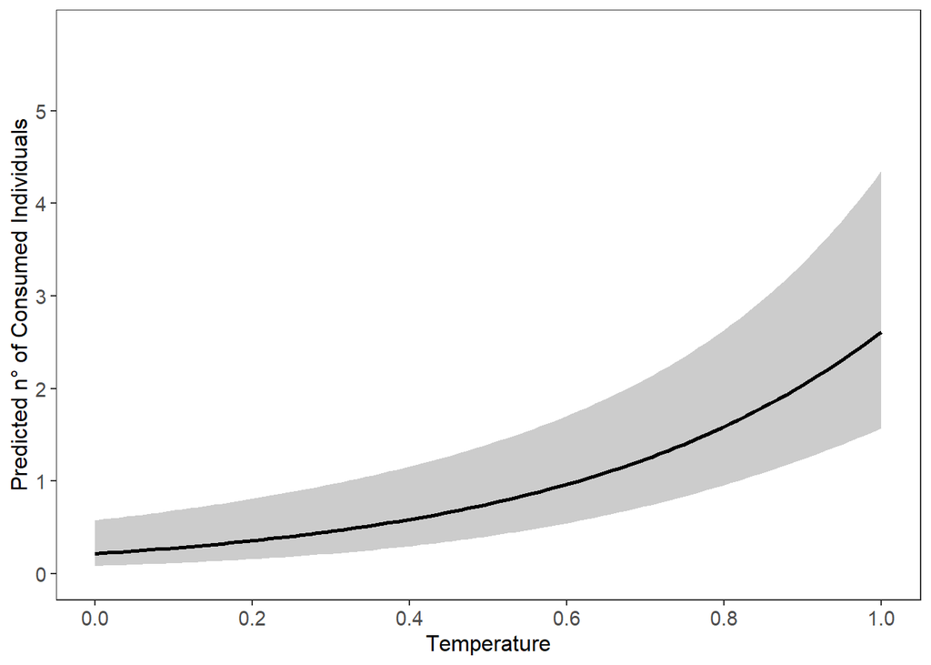

```r
library("mgcv")
newdata_C2 <- data.frame(
  Temperature = rep(seq(from = min(Crabs2_stand$Temperature), to = max(Crabs2_stand$Temperature), length.out = 100), 5), V_Visibility = 0, Predatory_crab = 0, Understorey_algae = 0)
newdata_C2 <- cbind(newdata_C2, predict(finalmodel_Crabs2$gam, newdata_C2 , type = "link", se.fit=TRUE))
newdata_C2 <- within(newdata_C2, {
  Consumed_individuals <- exp(fit)
  LL <- exp(fit - 1.96 * se.fit)
  UL <- exp(fit + 1.96 * se.fit)
})
ggplot(newdata_C2, aes(Temperature, Consumed_individuals)) +
  geom_ribbon(aes(ymin = LL, ymax = UL), alpha = .25) +
  geom_line(size = 1) +
  labs(x = "Temperature", y = "Predicted n° of Consumed Individuals")  + Theme1 +
  scale_x_continuous(breaks = seq(0, 1, 0.2)) +
  scale_y_continuous(limits = c(0,5.8), breaks = seq(0, 5, 1))
```

Save the plot in tiff format

```r
ggsave("TC2.tiff", units="mm", width=140, height=100, dpi=300, compression = 'lzw')
```

**2)** V_Visibility prediction

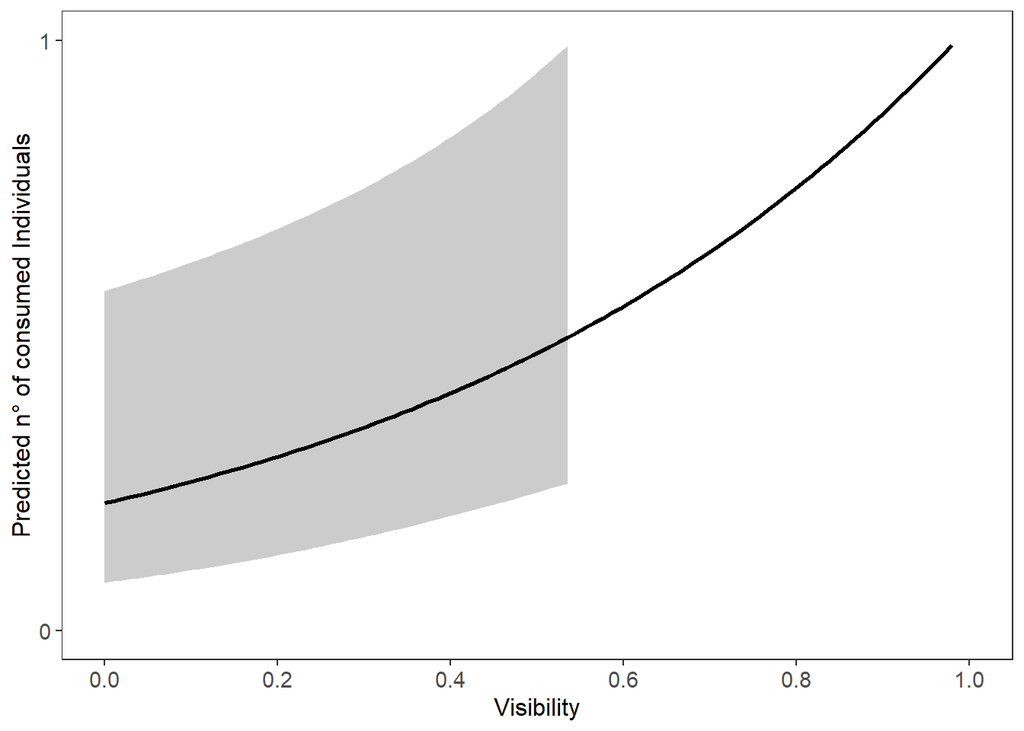

```r
newdata_C2 <- data.frame(
  V_Visibility = rep(seq(from = min(Crabs2_stand$V_Visibility), to = max(Crabs2_stand$V_Visibility), length.out = 100), 5), Temperature = 0, Predatory_crab = 0, Understorey_algae = 0)
newdata_C2 <- cbind(newdata_C2, predict(finalmodel_Crabs2$gam, newdata_C2 , type = "link", se.fit=TRUE))
newdata_C2 <- within(newdata_C2, {
  Consumed_individuals <- exp(fit)
  LL <- exp(fit - 1.96 * se.fit)
  UL <- exp(fit + 1.96 * se.fit)
})
ggplot(newdata_C2, aes(V_Visibility, Consumed_individuals)) +
  geom_ribbon(aes(ymin = LL, ymax = UL), alpha = .25) +
  geom_line(size = 1) +
  labs(x = "Visibility", y = "Predicted n° of consumed Individuals")  + Theme1 +
  scale_x_continuous(breaks = seq(0, 1, 0.2)) +
  scale_y_continuous(limits = c(0,1), breaks = seq(0, 1, 1))
```

Save the plot in tiff format

```r
ggsave("VC2.tiff", units="mm", width=140, height=100, dpi=300, compression = 'lzw')
```

**3)** Predatory crabs prediction

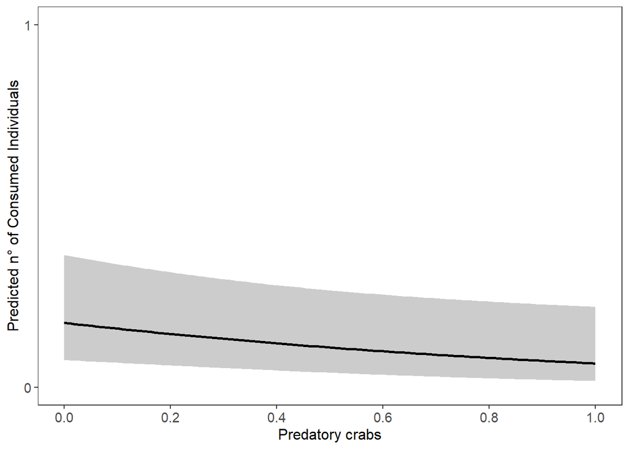

```r
newdata_C2 <- data.frame(
  Predatory_crab = rep(seq(from = min(Crabs2_stand$Predatory_crab), to = max(Crabs2_stand$Predatory_crab), length.out = 100), 5), Temperature = 0, V_Visibility = 0, Understorey_algae = 0)
newdata_C2 <- cbind(newdata_C2, predict(finalmodel_Crabs2$gam, newdata_C2 , type = "link", se.fit=TRUE))
newdata_C2 <- within(newdata_C2, {
  Consumed_individuals <- plogis(fit)
  LL <- plogis(fit - 1.96 * se.fit)
  UL <- plogis(fit + 1.96 * se.fit)
})
ggplot(newdata_C2, aes(Predatory_crab, Consumed_individuals)) +
  geom_ribbon(aes(ymin = LL, ymax = UL), alpha = .25) +
  geom_line(size = 1) +
  labs(x = "Predatory crabs", y = "Predicted n° of Consumed Individuals")  + Theme1 +
  scale_x_continuous(breaks = seq(0, 1, 0.2)) +
  scale_y_continuous(limits = c(0,1), breaks = seq(0, 1, 1))
```

Save the plot in tiff format

```r
ggsave("PCC2.tiff", units="mm", width=140, height=100, dpi=300, compression = 'lzw')
```

### **7b):** Crabs 24h

**1)** Temperature prediction

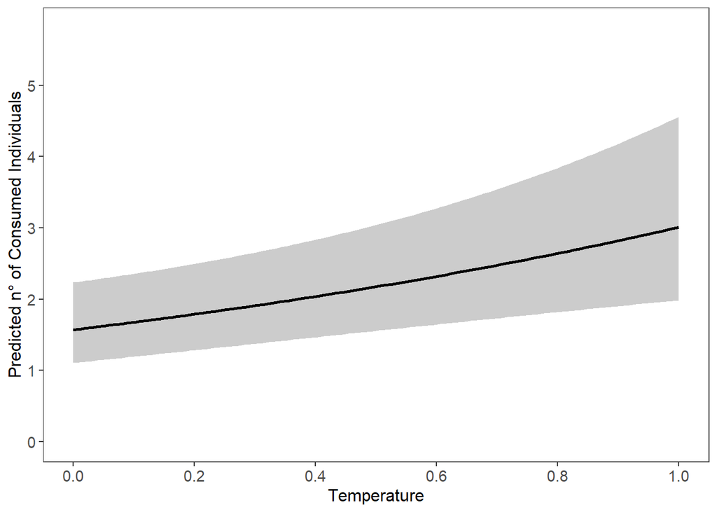

```r
newdata_C24 <- data.frame(
  Temperature = rep(seq(from = min(Crabs24_stand$Temperature), to = max(Crabs24_stand$Temperature), length.out = 100), 5), Salinity_ppt = 0)
newdata_C24 <- cbind(newdata_C24, predict(finalmodel_Crabs24$gam, newdata_C24 , type = "link", se.fit=TRUE))
newdata_C24 <- within(newdata_C24, {
  Consumed_individuals <- exp(fit)
  LL <- exp(fit - 1.96 * se.fit)
  UL <- exp(fit + 1.96 * se.fit)
})
ggplot(newdata_C24, aes(Temperature, Consumed_individuals)) +
  geom_ribbon(aes(ymin = LL, ymax = UL), alpha = .25) +
  geom_line(size = 1) +
  labs(x = "Temperature", y = "Predicted n° of Consumed Individuals")  + Theme1 +
  scale_x_continuous(breaks = seq(0, 1, 0.2))+
  scale_y_continuous(limits = c(0,5.8), breaks = seq(0, 5, 1))
```

Save the plot in tiff format

```r
ggsave("TC24.tiff", units="mm", width=140, height=100, dpi=300, compression = 'lzw')
```

**2)** Salinity prediction

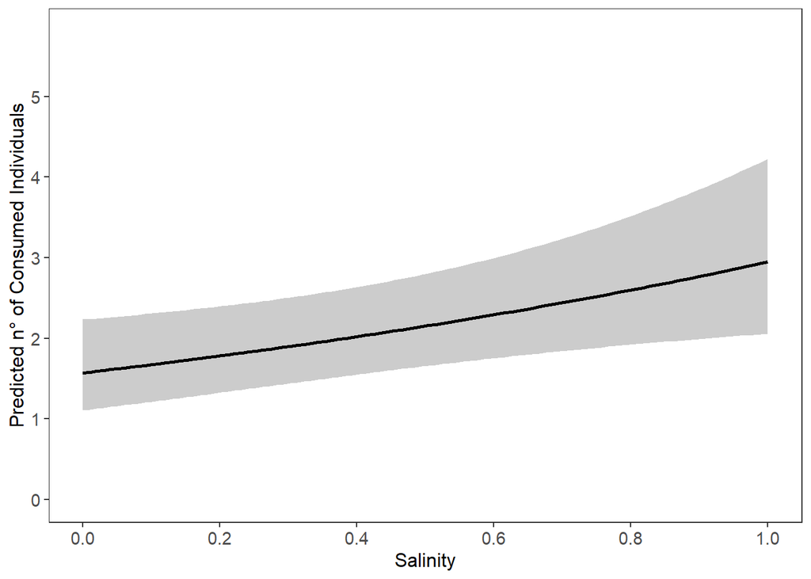

```r
newdata_C24 <- data.frame(
  Salinity_ppt = rep(seq(from = min(Crabs24_stand$Salinity_ppt), to = max(Crabs24_stand$Salinity_ppt), length.out = 100), 5), Temperature = 0)
newdata_C24 <- cbind(newdata_C24, predict(finalmodel_Crabs24$gam, newdata_C24 , type = "link", se.fit=TRUE))
newdata_C24 <- within(newdata_C24, {
  Consumed_individuals <- exp(fit)
  LL <- exp(fit - 1.96 * se.fit)
  UL <- exp(fit + 1.96 * se.fit)
})
ggplot(newdata_C24, aes(Salinity_ppt, Consumed_individuals)) +
  geom_ribbon(aes(ymin = LL, ymax = UL), alpha = .25) +
  geom_line(size = 1) +
  labs(x = "Salinity", y = "Predicted n° of Consumed Individuals")  + Theme1 +
  scale_x_continuous(breaks = seq(0, 1, 0.2))+
  scale_y_continuous(limits = c(0,5.8), breaks = seq(0, 5, 1))
```

Save the plot in tiff format

```r
ggsave("SC24.tiff", units="mm", width=140, height=100, dpi=300, compression = 'lzw')
```

### **7c):** Squidpops 2 h

**1)** Predatory crabs prediction

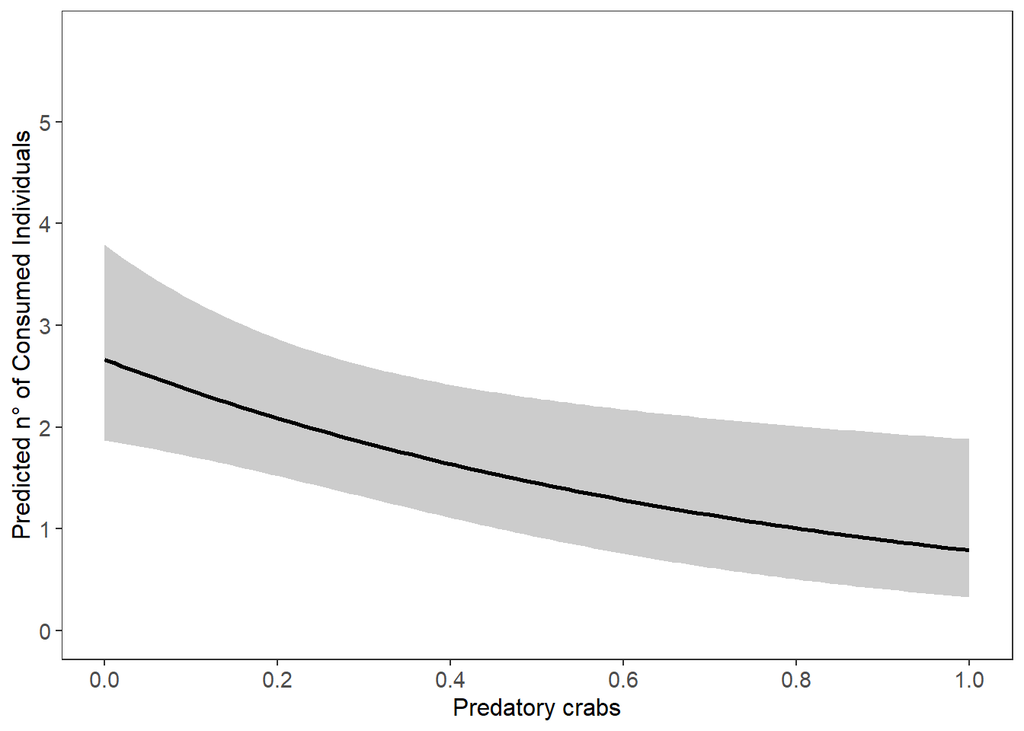

```r
newdata_S2 <- data.frame(
  Predatory_crab = rep(seq(from = min(Squidpops2_stand$Predatory_crab), to = max(Squidpops2_stand$Predatory_crab), length.out = 100), 5), Fish_size = 0, Temperature = 0, D_oxygen_mgL = 0, Kelp = 0)
newdata_S2 <- cbind(newdata_S2, predict(finalmodel_Squidpops2$gam, newdata_S2 , type = "link", se.fit=TRUE))
newdata_S2 <- within(newdata_S2, {
  Consumed_individuals <- exp(fit)
  LL <- exp(fit - 1.96 * se.fit)
  UL <- exp(fit + 1.96 * se.fit)
})
ggplot(newdata_S2, aes(Predatory_crab, Consumed_individuals)) +
  geom_ribbon(aes(ymin = LL, ymax = UL), alpha = .25) +
  geom_line(size = 1) +
  labs(x = "Predatory crabs", y = "Predicted n° of Consumed Individuals")  + Theme1 +
  scale_x_continuous(breaks = seq(0, 1, 0.2))+
  scale_y_continuous(limits = c(0,5.8), breaks = seq(0, 5, 1))
```

Save the plot in tiff format

```r
ggsave("PCS2.tiff", units="mm", width=140, height=100, dpi=300, compression = 'lzw')
```

**2)** Fish size prediction

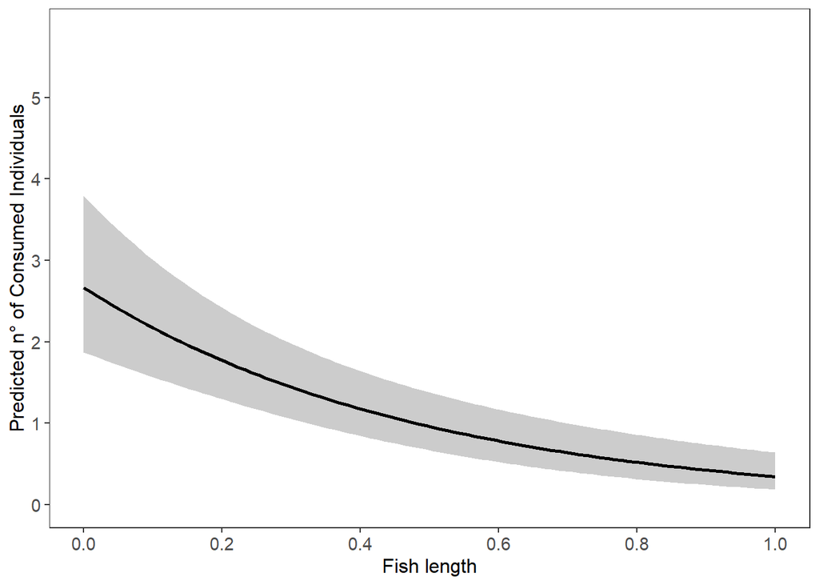

```r
newdata_S2 <- data.frame(
  Fish_size = rep(seq(from = min(Squidpops2_stand$Fish_size), to = max(Squidpops2_stand$Fish_size), length.out = 100), 5), Predatory_crab = 0, Temperature = 0, D_oxygen_mgL = 0, Kelp = 0)
newdata_S2 <- cbind(newdata_S2, predict(finalmodel_Squidpops2$gam, newdata_S2 , type = "link", se.fit=TRUE))
newdata_S2 <- within(newdata_S2, {
  Consumed_individuals <- exp(fit)
  LL <- exp(fit - 1.96 * se.fit)
  UL <- exp(fit + 1.96 * se.fit)
})
ggplot(newdata_S2, aes(Fish_size, Consumed_individuals)) +
  geom_ribbon(aes(ymin = LL, ymax = UL), alpha = .25) +
  geom_line(size = 1) +
  labs(x = "Fish length", y = "Predicted n° of Consumed Individuals")  + Theme1 +
  scale_x_continuous(breaks = seq(0, 1, 0.2))+
  scale_y_continuous(limits = c(0,5.8), breaks = seq(0, 5, 1))
```

Save the plot in tiff format

```r
ggsave("FLS2.tiff", units="mm", width=140, height=100, dpi=300, compression = 'lzw')
```

**3)** Dissolved oxygen prediction

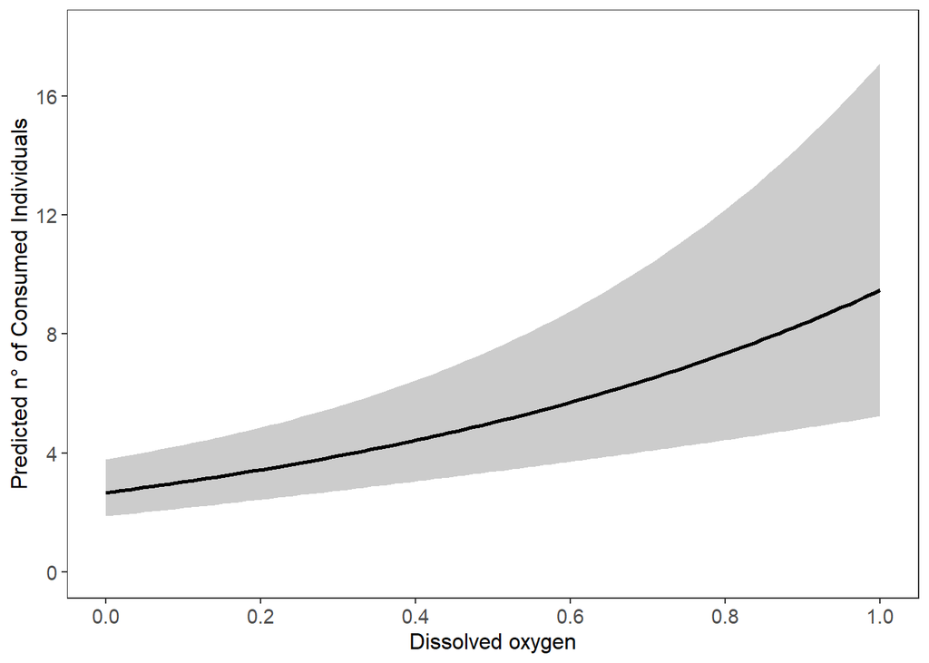

```r
newdata_S2 <- data.frame(
  D_oxygen_mgL = rep(seq(from = min(Squidpops2_stand$D_oxygen_mgL), to = max(Squidpops2_stand$D_oxygen_mgL), length.out = 100), 5), Predatory_crab = 0, Temperature = 0, Fish_size = 0, Kelp = 0)
newdata_S2 <- cbind(newdata_S2, predict(finalmodel_Squidpops2$gam, newdata_S2 , type = "link", se.fit=TRUE))
newdata_S2 <- within(newdata_S2, {
  Consumed_individuals <- exp(fit)
  LL <- exp(fit - 1.96 * se.fit)
  UL <- exp(fit + 1.96 * se.fit)
})
ggplot(newdata_S2, aes(D_oxygen_mgL, Consumed_individuals)) +
  geom_ribbon(aes(ymin = LL, ymax = UL), alpha = .25) +
  geom_line(size = 1) +
  labs(x = "Dissolved oxygen", y = "Predicted n° of Consumed Individuals")  + Theme1 +
  scale_x_continuous(breaks = seq(0, 1, 0.2))+
  scale_y_continuous(limits = c(0,18), breaks = seq(0, 16, 4))
```

Save the plot in tiff format

```r
ggsave("DOS2.tiff", units="mm", width=140, height=100, dpi=300, compression = 'lzw')
```

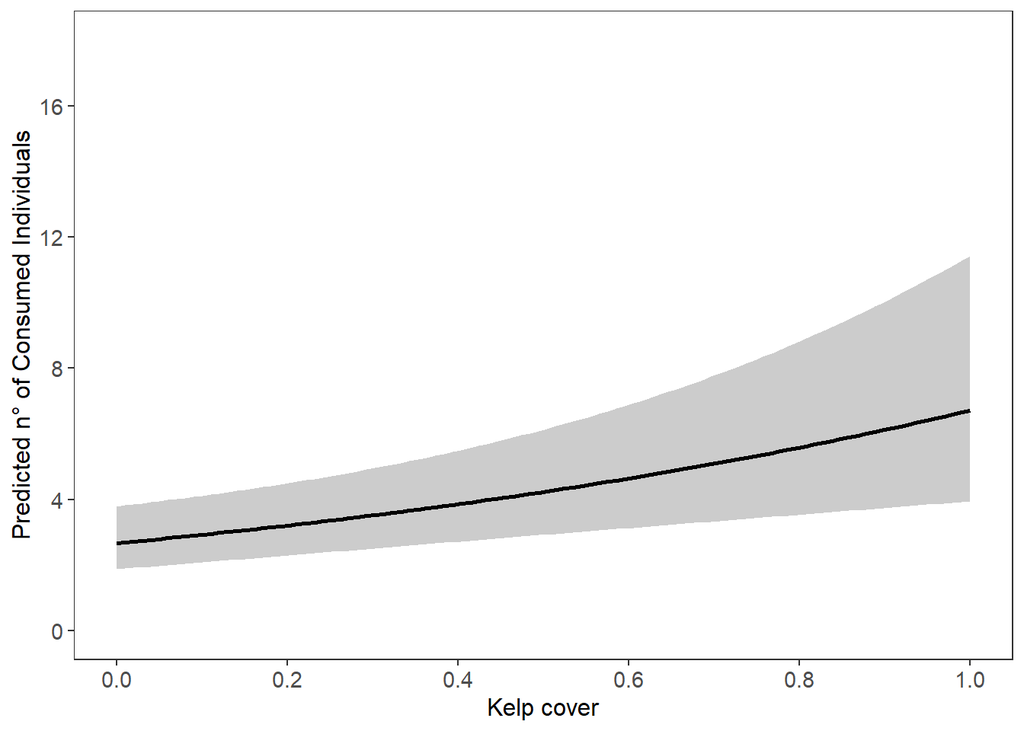

```r
newdata_S2 <- data.frame(
  Kelp = rep(seq(from = min(Squidpops2_stand$Kelp), to = max(Squidpops2_stand$Kelp), length.out = 100), 5), Predatory_crab = 0, Temperature = 0, Fish_size = 0, D_oxygen_mgL = 0)
newdata_S2 <- cbind(newdata_S2, predict(finalmodel_Squidpops2$gam, newdata_S2 , type = "link", se.fit=TRUE))
newdata_S2 <- within(newdata_S2, {
  Consumed_individuals <- exp(fit)
  LL <- exp(fit - 1.96 * se.fit)
  UL <- exp(fit + 1.96 * se.fit)
})
ggplot(newdata_S2, aes(Kelp, Consumed_individuals)) +
  geom_ribbon(aes(ymin = LL, ymax = UL), alpha = .25) +
  geom_line(size = 1) +
  labs(x = "Kelp cover", y = "Predicted n° of Consumed Individuals")  + Theme1 +
  scale_x_continuous(breaks = seq(0, 1, 0.2))+
  scale_y_continuous(limits = c(0,18), breaks = seq(0, 16, 4))
```

Save the plot in tiff format

```r
ggsave("KS2.tiff", units="mm", width=140, height=100, dpi=300, compression = 'lzw')
```

### **7d):** Squidpops 24 h

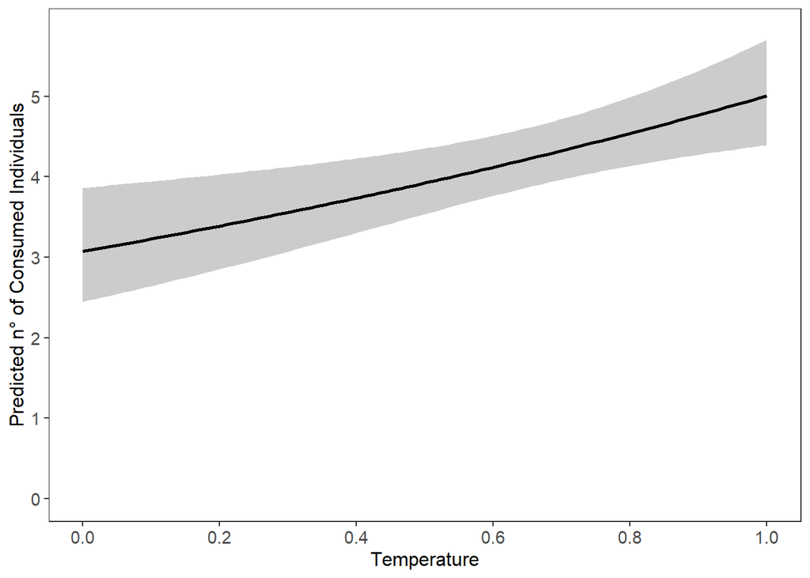

```r
newdata_S24 <- data.frame(
  Temperature = rep(seq(from = min(Squidpops24_stand$Temperature), to = max(Squidpops24_stand$Temperature), length.out = 100), 5))
newdata_S24 <- cbind(newdata_S24, predict(finalmodel_Squidpops24$gam, newdata_S24 , type = "link", se.fit=TRUE))
newdata_S24 <- within(newdata_S24, {
  Consumed_individuals <- exp(fit)
  LL <- exp(fit - 1.96 * se.fit)
  UL <- exp(fit + 1.96 * se.fit)
})
ggplot(newdata_S24, aes(Temperature, Consumed_individuals)) +
  geom_ribbon(aes(ymin = LL, ymax = UL), alpha = .25) +
  geom_line(size = 1) +
  labs(x = "Temperature", y = "Predicted n° of Consumed Individuals")  + Theme1 +
  scale_x_continuous(breaks = seq(0, 1, 0.2))+
  scale_y_continuous(limits = c(0,5.8), breaks = seq(0, 5, 1))
```

Save the plot in tiff format

```r
ggsave("TS24.tiff", units="mm", width=160, height=100, dpi=300, compression = 'lzw')
```

### **7e):** Seaweed consumption 24 h

**1)** Understorey algae prediction

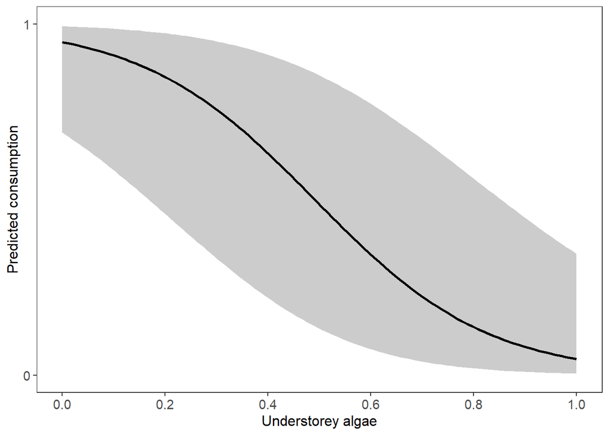

```r
newdata_L24 <- data.frame(Understorey_algae = rep(seq(from = min(Herb_all_stand$Understorey_algae), to = max(Herb_all_stand$Understorey_algae), length.out = 100), 5), Omnivorous_crab = 0, Herbivore_gastropod = 0, Temperature = 0)
newdata_L24 <- cbind(newdata_L24, predict(finalmodel_herbivory$gam, newdata_L24 , type = "link", se.fit=TRUE))
newdata_L24 <- within(newdata_L24, {
  Consumption <- plogis(fit)
  LL <- plogis(fit - 1.96 * se.fit)
  UL <- plogis(fit + 1.96 * se.fit)
})
ggplot(newdata_L24, aes(Understorey_algae, Consumption)) +
  geom_ribbon(aes(ymin = LL, ymax = UL), alpha = .25) +
  geom_line(size = 1) +
  labs(x = "Understorey algae", y = "Predicted consumption")  + Theme1 +
  scale_x_continuous(limits = c(0,1), breaks = seq(0, 1, 0.2))+
  scale_y_continuous(limits = c(0,1), breaks = seq(0, 5, 1))
```

Save the plot in tiff format

```r
ggsave("LUA24.tiff", units="mm", width=140, height=100, dpi=300, compression = 'lzw')
```

**2)** Omnivorous crab prediction

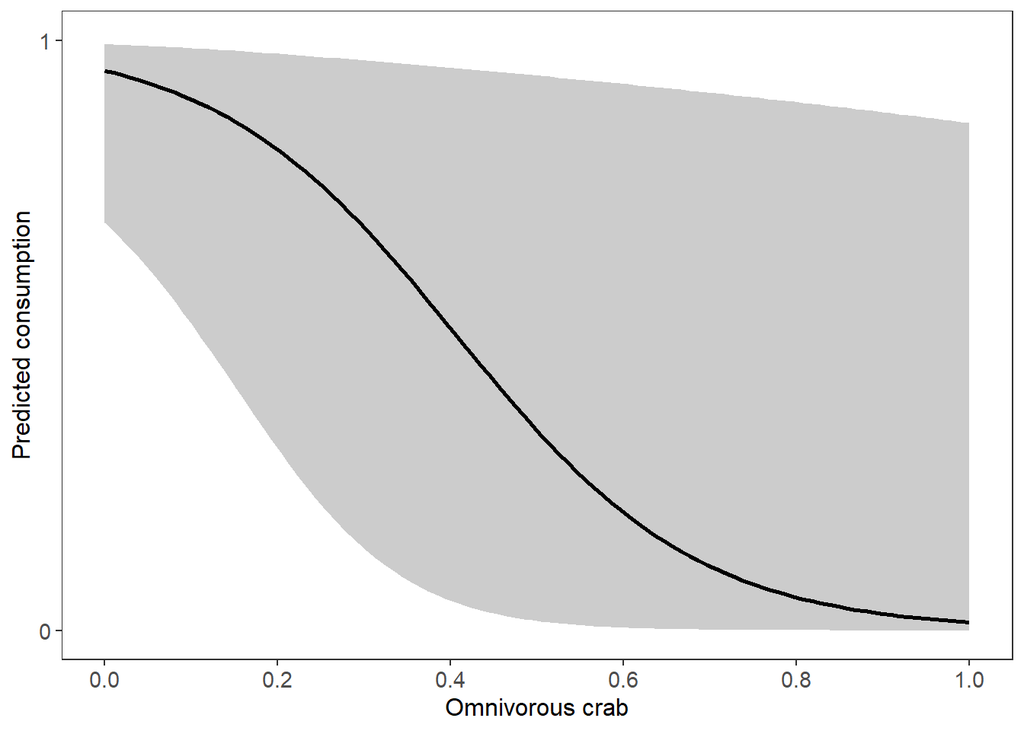

```r
newdata_L24 <- data.frame(Omnivorous_crab = rep(seq(from = min(Herb_all_stand$Omnivorous_crab), to = max(Herb_all_stand$Omnivorous_crab), length.out = 100), 5), Understorey_algae = 0, Herbivore_gastropod = 0, Temperature = 0)
newdata_L24 <- cbind(newdata_L24, predict(finalmodel_herbivory$gam, newdata_L24 , type = "link", se.fit=TRUE))
newdata_L24 <- within(newdata_L24, {
  Consumption <- plogis(fit)
  LL <- plogis(fit - 1.96 * se.fit)
  UL <- plogis(fit + 1.96 * se.fit)
})
ggplot(newdata_L24, aes(Omnivorous_crab, Consumption)) +
  geom_ribbon(aes(ymin = LL, ymax = UL), alpha = .25) +
  geom_line(size = 1) +
  labs(x = "Omnivorous crab", y = "Predicted consumption")  + Theme1 +
  scale_x_continuous(limits = c(0,1), breaks = seq(0, 1, 0.2))+
  scale_y_continuous(limits = c(0,1), breaks = seq(0, 5, 1))
```

Save the plot in tiff format

```r
ggsave("LO24.tiff", units="mm", width=140, height=100, dpi=300, compression = 'lzw')
```

**2)** Herbivore gastropods prediction

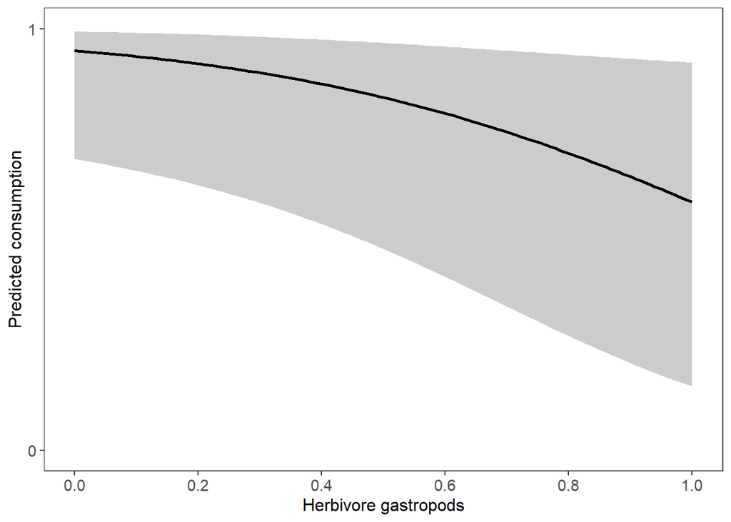

```r
newdata_L24 <- data.frame(Herbivore_gastropod  = rep(seq(from = min(Herb_all_stand$Herbivore_gastropod), to = max(Herb_all_stand$Herbivore_gastropod ), length.out = 100), 5), Understorey_algae = 0, Omnivorous_crab = 0, Temperature = 0)
newdata_L24 <- cbind(newdata_L24, predict(finalmodel_herbivory$gam, newdata_L24 , type = "link", se.fit=TRUE))
newdata_L24 <- within(newdata_L24, {
  Consumption <- plogis(fit)
  LL <- plogis(fit - 1.96 * se.fit)
  UL <- plogis(fit + 1.96 * se.fit)
})
ggplot(newdata_L24, aes(Herbivore_gastropod, Consumption)) +
  geom_ribbon(aes(ymin = LL, ymax = UL), alpha = .25) +
  geom_line(size = 1) +
  labs(x = "Herbivore gastropods", y = "Predicted consumption")  + Theme1 +
  scale_x_continuous(limits = c(0,1), breaks = seq(0, 1, 0.2))+
  scale_y_continuous(limits = c(0,1), breaks = seq(0, 5, 1))
```

Save the plot in tiff format

```r
ggsave("LHG24.tiff", units="mm", width=140, height=100, dpi=300, compression = 'lzw')
```

## **Part 8**: Phlorotannins

### **8a)** Latitudinal variation in phlorotannins

Check visual relationships

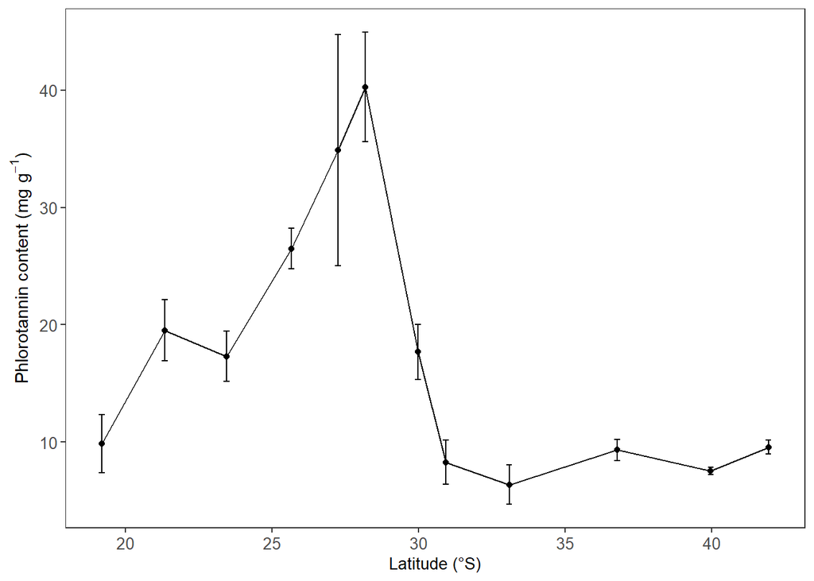

```r
Phlorotannins_mean$Latitude <- Phlorotannins_mean$Latitude*-1

Phlorotannins_mean%>%
ggplot(aes(x= Latitude, y=phloro_mean)) +
  geom_line() +
  geom_point()+
  geom_errorbar(aes(ymin=phloro_mean-se, ymax=phloro_mean+se), width=.2,
                 position=position_dodge(0.05)) +
Theme1 +
labs( y="Phlorotannin content (mg"~g^-1*")", x="Latitude (°S)") +
theme(axis.text.y = element_text(size = 10), axis.title.y = element_text(size = 11), axis.text.x = element_text(size = 10), axis.title.x =     element_text(size = 10), plot.title=element_text(hjust=0.95, vjust=-8, size=10))
```

Save the plot in tiff format

```r
ggsave("Phloro.tiff", units="mm", width=160, height=100, dpi=300, compression = 'lzw')
```

### **8b)** Relationship of phlorotannin content and herbivory

```r
model_phloro <- gamm4(Consumption ~ phloro_mean, data = Herbivory_phloro, random =~(1|Site) , family = binomial)
summary(model_phloro$gam)
```

```
##
## Family: binomial
## Link function: logit
##
## Formula:
## Consumption ~ phloro_mean
##
## Parametric coefficients:
##             Estimate Std. Error z value Pr(>|z|)
## (Intercept)  1.68850    1.05731   1.597   0.1103
## phloro_mean -0.18093    0.05664  -3.194   0.0014 **
## ---
## Signif. codes:  0 '***' 0.001 '**' 0.01 '*' 0.05 '.' 0.1 ' ' 1
##
##
## R-sq.(adj) =  0.156
## glmer.ML = 422.33  Scale est. = 1         n = 590
```

Plot result

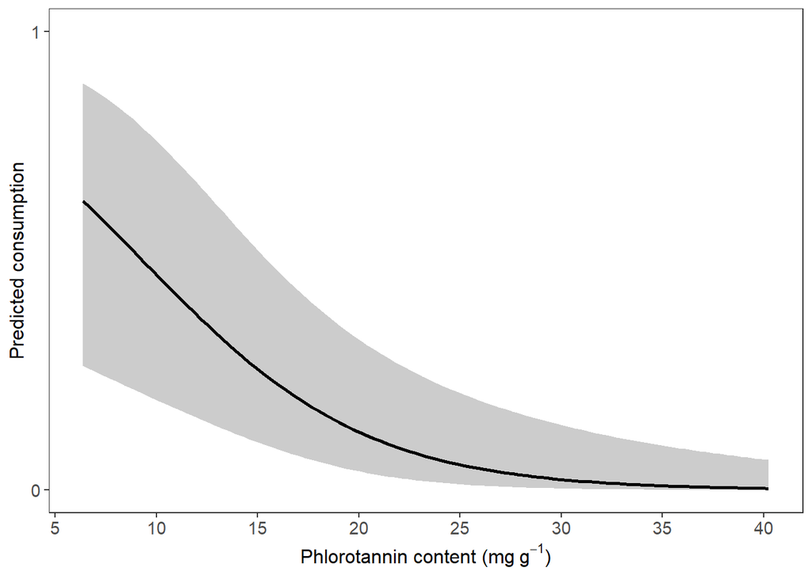

```r
newdata_P <- data.frame(phloro_mean  = rep(seq(from = min(Herbivory_phloro$phloro_mean), to = max(Herbivory_phloro$phloro_mean), length.out = 100), 5))
newdata_P <- cbind(newdata_P, predict(model_phloro$gam, newdata_P , type = "link", se.fit=TRUE))
newdata_P <- within(newdata_P, {
  Consumption <- plogis(fit)
  LL <- plogis(fit - 1.96 * se.fit)
  UL <- plogis(fit + 1.96 * se.fit)
})
ggplot(newdata_P, aes(phloro_mean, Consumption)) +
  geom_ribbon(aes(ymin = LL, ymax = UL), alpha = .25) +
  geom_line(size = 1) +
  labs(x = "Phlorotannin content (mg"~g^-1*")", y = "Predicted consumption")  + Theme1 +
  scale_x_continuous(breaks = seq(0, 40, 5))+
  scale_y_continuous(limits = c(0,1), breaks = seq(0, 5, 1))
```

Save the plot in tiff format

```r
ggsave("PhloroPred.tiff", units="mm", width=160, height=100, dpi=300, compression = 'lzw')
```

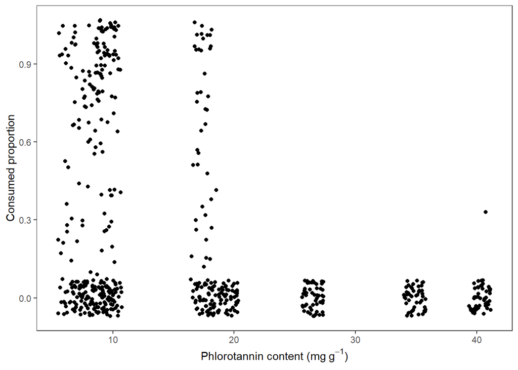

```r
ggplot(Herbivory_phloro,
                       aes(phloro_mean, Consumed_proportion)) +
  geom_jitter(width = 0.9, height =  0.07) +
  theme_bw() +
  theme(panel.grid.major = element_line(colour = "white"),
        panel.grid.minor = element_line(colour = "white")) +
  labs(y="Consumed proportion", x = "Phlorotannin content (mg"~g^-1*")")
```

## **Part 9**: R Session Information

In this part, information about the operating system and R packages attached during the production of this document can be found

```r
sessionInfo() %>% pander
```

**R version 4.1.1 (2021-08-10)**

**Platform:** x86_64-w64-mingw32/x64 (64-bit)

**locale:** *LC_COLLATE=English_United Kingdom.1252*, *LC_CTYPE=English_United Kingdom.1252*, *LC_MONETARY=English_United Kingdom.1252*, *LC_NUMERIC=C* and *LC_TIME=English_United Kingdom.1252*

**attached base packages:** *stats*, *graphics*, *grDevices*, *utils*, *datasets*, *methods* and *base*

**other attached packages:** *pander(v.0.6.4)*, *gamm4(v.0.2-6)*, *mgcv(v.1.8-36)*, *nlme(v.3.1-152)*, *lme4(v.1.1-27.1)*, *Matrix(v.1.3-4)*, *patchwork(v.1.1.1)*, *vegan(v.2.5-7)*, *lattice(v.0.20-44)*, *permute(v.0.9-5)*, *summarytools(v.1.0.0)*, *forcats(v.0.5.1)*, *stringr(v.1.4.0)*, *dplyr(v.1.0.7)*, *purrr(v.0.3.4)*, *readr(v.2.0.1)*, *tidyr(v.1.1.3)*, *tibble(v.3.1.4)*, *ggplot2(v.3.3.5)* and *tidyverse(v.1.3.1)*

**loaded via a namespace (and not attached):** *matrixStats(v.0.60.1)*, *fs(v.1.5.0)*, *lubridate(v.1.7.10)*, *httr(v.1.4.2)*, *tools(v.4.1.1)*, *backports(v.1.2.1)*, *utf8(v.1.2.2)*, *R6(v.2.5.1)*, *DBI(v.1.1.1)*, *colorspace(v.2.0-2)*, *withr(v.2.4.2)*, *tidyselect(v.1.1.1)*, *compiler(v.4.1.1)*, *cli(v.3.0.1)*, *rvest(v.1.0.1)*, *xml2(v.1.3.2)*, *labeling(v.0.4.2)*, *scales(v.1.1.1)*, *checkmate(v.2.0.0)*, *digest(v.0.6.27)*, *minqa(v.1.2.4)*, *rmarkdown(v.2.10)*, *base64enc(v.0.1-3)*, *pkgconfig(v.2.0.3)*, *htmltools(v.0.5.2)*, *highr(v.0.9)*, *dbplyr(v.2.1.1)*, *fastmap(v.1.1.0)*, *rlang(v.0.4.11)*, *readxl(v.1.3.1)*, *rstudioapi(v.0.13)*, *pryr(v.0.1.5)*, *farver(v.2.1.0)*, *generics(v.0.1.0)*, *jsonlite(v.1.7.2)*, *magrittr(v.2.0.1)*, *rapportools(v.1.0)*, *Rcpp(v.1.0.7)*, *munsell(v.0.5.0)*, *fansi(v.0.5.0)*, *lifecycle(v.1.0.0)*, *stringi(v.1.7.4)*, *yaml(v.2.2.1)*, *MASS(v.7.3-54)*, *plyr(v.1.8.6)*, *grid(v.4.1.1)*, *parallel(v.4.1.1)*, *crayon(v.1.4.1)*, *haven(v.2.4.3)*, *splines(v.4.1.1)*, *hms(v.1.1.0)*, *magick(v.2.7.3)*, *knitr(v.1.33)*, *pillar(v.1.6.2)*, *tcltk(v.4.1.1)*, *boot(v.1.3-28)*, *codetools(v.0.2-18)*, *reprex(v.2.0.1)*, *glue(v.1.4.2)*, *evaluate(v.0.14)*, *modelr(v.0.1.8)*, *vctrs(v.0.3.8)*, *nloptr(v.1.2.2.2)*, *tzdb(v.0.1.2)*, *cellranger(v.1.1.0)*, *gtable(v.0.3.0)*, *assertthat(v.0.2.1)*, *xfun(v.0.25)*, *broom(v.0.7.9)*, *cluster(v.2.1.2)* and *ellipsis(v.0.3.2)*